# Does adding temp * julian date interaction improve model fit for results?

```
G3;Model has sqrt-transformed response. Back-transforming predictions to original response scale. Standard
  errors are still on the transformed scale.
gG3;Data points may overlap. Use the `jitter` argument to add some amount of random variation to the
  location of data points and avoid overplotting.
gScale for colour is already present.
```

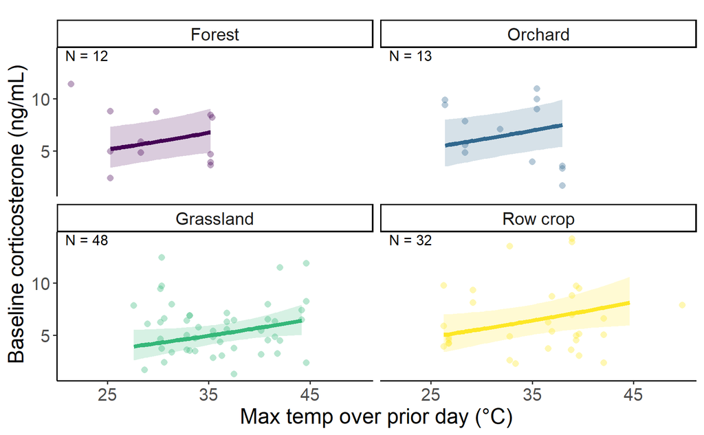

```r
(figs2_priordayt_tres <- ggpredict(s1_lintemp_addmax,terms = c("maxt_prior_scaled [all]","habitat"),bias_correction = TRUE) %>%
    plot(line_size = 1.5,alpha = .2,show_data = TRUE,limit_range = TRUE) +
    aes(linetype = .data[["group"]]) +
    theme_classic() +
    facet_wrap(~ group, ncol = 2) +
    xlab("Max temp over prior day (\u00b0C)") +
    ylab("Baseline corticosterone (ng/mL)") +
    scale_fill_viridis(discrete = TRUE) +
    scale_color_viridis(discrete = TRUE) +
    theme(text = element_text(size = 16)) +
    labs(title = element_blank()) +
    scale_x_continuous(trans = temp_trans_s1_priordayt_tres,
                       breaks = c((25-mean_temp_s1_priordayt_tres)/sd_temp_s1_priordayt_tres,
                                  (35-mean_temp_s1_priordayt_tres)/sd_temp_s1_priordayt_tres,
                                  (45-mean_temp_s1_priordayt_tres)/sd_temp_s1_priordayt_tres,
                                  (55-mean_temp_s1_priordayt_tres)/sd_temp_s1_priordayt_tres,
                                  (65-mean_temp_s1_priordayt_tres)/sd_temp_s1_priordayt_tres),
                       # breaks = c(20,30,40,50),
                       # labels = c("20","30","40","50"),
                       # limits = c((15-mean(g$meanmaxtempI,na.rm = TRUE))/sd(g$meanmaxtempI,na.rm = TRUE),
                       #            (55-mean(g$meanmaxtempI,na.rm = TRUE))/sd(g$meanmaxtempI,na.rm = TRUE))
                       # limits = c(18,5)
    ) +
    scale_linetype_manual(values = c("solid","solid","solid","solid")) +
    #ylim(-5,5) +
    geom_text(data = dat_text_s1_priordayt_tres, mapping = aes(x = -Inf, y = Inf,label = label),hjust = -.2, vjust = 1.2,inherit.aes = FALSE) +
    theme(legend.position = "none")
)
```

```
G3;Model has sqrt-transformed response. Back-transforming predictions to original response scale. Standard
  errors are still on the transformed scale.
gG3;Data points may overlap. Use the `jitter` argument to add some amount of random variation to the
  location of data points and avoid overplotting.
g
```

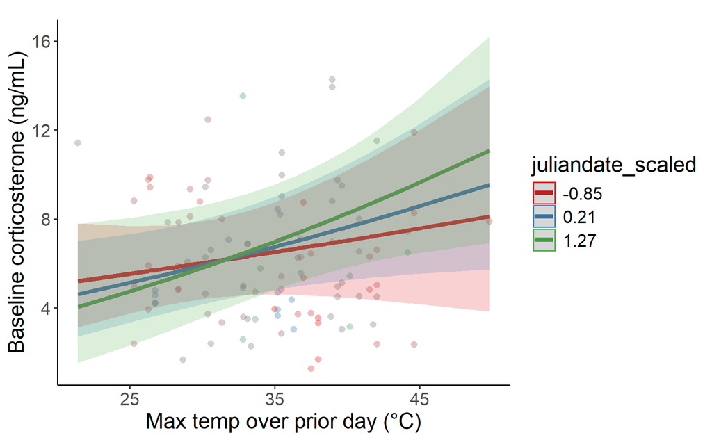

```r
(figs2_priordayt_tres <- ggpredict(s1_lintemp_addmax,terms = c("maxt_prior_scaled [all]","juliandate_scaled"),bias_correction = TRUE) %>%
    plot(line_size = 1.5,alpha = .2,show_data = TRUE,limit_range = TRUE) +
    # aes(linetype = .data[["group"]]) +
    theme_classic() +
    # facet_wrap(~ group, ncol = 2) +
    xlab("Max temp over prior day (\u00b0C)") +
    ylab("Baseline corticosterone (ng/mL)") +
    # scale_fill_viridis(discrete = TRUE) +
    # scale_color_viridis(discrete = TRUE) +
    theme(text = element_text(size = 16)) +
    labs(title = element_blank()) +
    scale_x_continuous(trans = temp_trans_s1_priordayt_tres,
                       breaks = c((25-mean_temp_s1_priordayt_tres)/sd_temp_s1_priordayt_tres,
                                  (35-mean_temp_s1_priordayt_tres)/sd_temp_s1_priordayt_tres,
                                  (45-mean_temp_s1_priordayt_tres)/sd_temp_s1_priordayt_tres,
                                  (55-mean_temp_s1_priordayt_tres)/sd_temp_s1_priordayt_tres,
                                  (65-mean_temp_s1_priordayt_tres)/sd_temp_s1_priordayt_tres),
                       # breaks = c(20,30,40,50),
                       # labels = c("20","30","40","50"),
                       # limits = c((15-mean(g$meanmaxtempI,na.rm = TRUE))/sd(g$meanmaxtempI,na.rm = TRUE),
                       #            (55-mean(g$meanmaxtempI,na.rm = TRUE))/sd(g$meanmaxtempI,na.rm = TRUE))
                       # limits = c(18,5)
    ) # +
#     scale_linetype_manual(values = c("dotted","dashed","dotted","dotted")) +
#     #ylim(-5,5) +
#     geom_text(data = dat_text_s1_priordayt_tres, mapping = aes(x = -Inf, y = Inf,label = label),hjust = -.2, vjust = 1.2,inherit.aes = FALSE) +
#     theme(legend.position = "none")
)
```

Interaction not significant

### Abs difference by prior day temp

#### WEBL

```r
prior_model <- lmerTest::lmer(sqrt(abs_change_cort) ~ maxt_prior_scaled + mint_prior_scaled + habitat + age_scaled + juliandate_scaled + year_fct + (1|attempt_id),data = dplyr::filter(g,Species == "WEBL",!is.na(maxt_prior),!is.na(mint_prior)) %>%
                                      mutate(across(c(gweight,maxt_prior,mint_prior,juliandate,brood_size,age),
                                                    ~ scale(.x)[,1],
                                                    .names = "{.col}_scaled"),
                                             maxt_prior_scaled_sq = maxt_prior_scaled * maxt_prior_scaled))
```

```
G2;H2;Warningh in sqrt(abs_change_cort) : NaNs producedg
G2;H2;Warningh in sqrt(abs_change_cort) : NaNs producedg
G2;H2;Warningh in sqrt(abs_change_cort) : NaNs producedg
G2;H2;Warningh in sqrt(abs_change_cort) : NaNs producedg
G2;H2;Warningh in sqrt(abs_change_cort) : NaNs producedg
G2;H2;Warningh in sqrt(abs_change_cort) : NaNs producedg
```

```r
abs_lintemp <- lmerTest::lmer(sqrt(abs_change_cort) ~ maxt_prior_scaled * habitat + mint_prior_scaled * habitat + age_scaled + maxt_prior_scaled * juliandate_scaled + year_fct + (1|attempt_id),data = dplyr::filter(g,Species == "WEBL",!is.na(maxt_prior),!is.na(mint_prior)) %>%
                                mutate(across(c(gweight,maxt_prior,mint_prior,juliandate,brood_size,age),
                                              ~ scale(.x)[,1],
                                              .names = "{.col}_scaled"),
                                       maxt_prior_scaled_sq = maxt_prior_scaled * maxt_prior_scaled))
```

```
G2;H2;Warningh in sqrt(abs_change_cort) : NaNs producedg
G2;H2;Warningh in sqrt(abs_change_cort) : NaNs producedg
G2;H2;Warningh in sqrt(abs_change_cort) : NaNs producedg
G2;H2;Warningh in sqrt(abs_change_cort) : NaNs producedg
G2;H2;Warningh in sqrt(abs_change_cort) : NaNs producedg
G2;H2;Warningh in sqrt(abs_change_cort) : NaNs producedg
```

```r
abs_lintemp_addmax <- lmerTest::lmer(sqrt(abs_change_cort) ~ maxt_prior_scaled + mint_prior_scaled * habitat + age_scaled + maxt_prior_scaled * juliandate_scaled + year_fct + (1|attempt_id),data = dplyr::filter(g,Species == "WEBL",!is.na(maxt_prior),!is.na(mint_prior)) %>%
                                       mutate(across(c(gweight,maxt_prior,mint_prior,juliandate,brood_size,age),
                                                     ~ scale(.x)[,1],
                                                     .names = "{.col}_scaled"),
                                              maxt_prior_scaled_sq = maxt_prior_scaled * maxt_prior_scaled))
```

```
G2;H2;Warningh in sqrt(abs_change_cort) : NaNs producedg
G2;H2;Warningh in sqrt(abs_change_cort) : NaNs producedg
G2;H2;Warningh in sqrt(abs_change_cort) : NaNs producedg
G2;H2;Warningh in sqrt(abs_change_cort) : NaNs producedg
G2;H2;Warningh in sqrt(abs_change_cort) : NaNs producedg
G2;H2;Warningh in sqrt(abs_change_cort) : NaNs producedg
```

```r
abs_lintemp_addmin <- lmerTest::lmer(sqrt(abs_change_cort) ~ maxt_prior_scaled * habitat + mint_prior_scaled + age_scaled + maxt_prior_scaled * juliandate_scaled + year_fct + (1|attempt_id),data = dplyr::filter(g,Species == "WEBL",!is.na(maxt_prior),!is.na(mint_prior)) %>%
                                       mutate(across(c(gweight,maxt_prior,mint_prior,juliandate,brood_size,age),
                                                     ~ scale(.x)[,1],
                                                     .names = "{.col}_scaled"),
                                              maxt_prior_scaled_sq = maxt_prior_scaled * maxt_prior_scaled))
```

```
G2;H2;Warningh in sqrt(abs_change_cort) : NaNs producedg
G2;H2;Warningh in sqrt(abs_change_cort) : NaNs producedg
G2;H2;Warningh in sqrt(abs_change_cort) : NaNs producedg
G2;H2;Warningh in sqrt(abs_change_cort) : NaNs producedg
G2;H2;Warningh in sqrt(abs_change_cort) : NaNs producedg
G2;H2;Warningh in sqrt(abs_change_cort) : NaNs producedg
```

```r
abs_lintemp_noint <- lmerTest::lmer(sqrt(abs_change_cort) ~ maxt_prior_scaled + mint_prior_scaled + habitat + age_scaled + maxt_prior_scaled * juliandate_scaled + year_fct + (1|attempt_id),data = dplyr::filter(g,Species == "WEBL",!is.na(maxt_prior),!is.na(mint_prior)) %>%
                                      mutate(across(c(gweight,maxt_prior,mint_prior,juliandate,brood_size,age),
                                                    ~ scale(.x)[,1],
                                                    .names = "{.col}_scaled"),
                                             maxt_prior_scaled_sq = maxt_prior_scaled * maxt_prior_scaled))
```

```
G2;H2;Warningh in sqrt(abs_change_cort) : NaNs producedg
G2;H2;Warningh in sqrt(abs_change_cort) : NaNs producedg
G2;H2;Warningh in sqrt(abs_change_cort) : NaNs producedg
G2;H2;Warningh in sqrt(abs_change_cort) : NaNs producedg
G2;H2;Warningh in sqrt(abs_change_cort) : NaNs producedg
G2;H2;Warningh in sqrt(abs_change_cort) : NaNs producedg
```

```r
c1 <- anova(abs_lintemp,abs_lintemp_addmin,abs_lintemp_noint) %>% tibble() %>% mutate(Model = c("no interaction","single interaction","both interacting"),.before = npar)
```

```
G3;refitting model(s) with ML (instead of REML)
g
```

```r
c2 <- anova(abs_lintemp,abs_lintemp_addmax,abs_lintemp_noint) %>% tibble() %>% mutate(Model = c("no interaction","single interaction","both interacting"),.before = npar)
```

```
G3;refitting model(s) with ML (instead of REML)
g
```

```r
(int_tab_abs_priordayt_webl <- bind_rows(c1,c2) %>%
    as.tibble() %>%
    mutate(across(where(is.numeric),~round(.x,digits = 3)),
           P = `Pr(>Chisq)`) %>%
    dplyr::select(Model,AIC,Chisq,P) %>%
    mutate(max_or_min = c(rep("Max temp",times = 3),rep("Min temp",times = 3)),
           across(c(AIC,Chisq), ~ round(.x, digits = 2)),
           P = if_else(P < 0.001,"<0.001",as.character(P))) %>%
    group_by(max_or_min) %>% gt())
```

| Model | AIC | Chisq | P |
| --- | --- | --- | --- |
| Max temp |  |  |  |
| no interaction | 561.97 | NA | NA |
| single interaction | 566.13 | 1.84 | 0.605 |
| both interacting | 568.05 | 4.08 | 0.253 |
| Min temp |  |  |  |
| no interaction | 561.97 | NA | NA |
| single interaction | 564.96 | 3.01 | 0.39 |
| both interacting | 568.05 | 2.91 | 0.405 |

```r
# gtsave(int_tab_abs_priordayt_webl,"figures/int_tab_abs_priordayt_webl.html")

summary(abs_lintemp_noint)
```

```
Linear mixed model fit by REML. t-tests use Satterthwaite's method ['lmerModLmerTest']
Formula: sqrt(abs_change_cort) ~ maxt_prior_scaled + mint_prior_scaled +
    habitat + age_scaled + maxt_prior_scaled * juliandate_scaled +      year_fct + (1 | attempt_id)
   Data: dplyr::filter(g, Species == "WEBL", !is.na(maxt_prior), !is.na(mint_prior)) %>%
    mutate(across(c(gweight, maxt_prior, mint_prior, juliandate,
        brood_size, age), ~scale(.x)[, 1], .names = "{.col}_scaled"),
        maxt_prior_scaled_sq = maxt_prior_scaled * maxt_prior_scaled)

REML criterion at convergence: 543.2

Scaled residuals:
     Min       1Q   Median       3Q      Max
-1.92326 -0.61599 -0.00913  0.59051  2.20929

Random effects:
 Groups     Name        Variance Std.Dev.
 attempt_id (Intercept) 2.112    1.453
 Residual               1.704    1.306
Number of obs: 142, groups:  attempt_id, 49

Fixed effects:
                                     Estimate Std. Error        df t value Pr(>|t|)
(Intercept)                           3.66143    0.53928  36.55653   6.789 5.75e-08 ***
maxt_prior_scaled                    -0.38905    0.25701 121.48550  -1.514   0.1327
mint_prior_scaled                     0.10511    0.24088 107.12421   0.436   0.6634
habitatOrchard                        0.51292    0.65740  36.46864   0.780   0.4403
habitatGrassland                      0.06861    0.78999  36.98537   0.087   0.9313
habitatRow crop                       0.54319    0.74121  35.60347   0.733   0.4685
age_scaled                            0.29551    0.15617 129.40807   1.892   0.0607 .
juliandate_scaled                    -0.29924    0.28678  49.71214  -1.043   0.3018
year_fct2023                         -0.17510    0.58673  41.28524  -0.298   0.7669
maxt_prior_scaled:juliandate_scaled  -0.16970    0.19886 112.39477  -0.853   0.3953
---
Signif. codes:  0 '***' 0.001 '**' 0.01 '*' 0.05 '.' 0.1 ' ' 1

Correlation of Fixed Effects:
            (Intr) mxt_p_ mnt_p_ hbttOr hbttGr hbttRc ag_scl jlndt_ y_2023
mxt_prr_scl  0.023
mnt_prr_scl  0.003 -0.387
habttOrchrd -0.720 -0.087 -0.144
hbttGrsslnd -0.563 -0.245  0.248  0.467
habittRwcrp -0.621 -0.163  0.027  0.531  0.447
age_scaled   0.000  0.120  0.200 -0.135  0.016 -0.106
julndt_scld  0.024 -0.355 -0.233  0.094 -0.052  0.132 -0.288
yer_fct2023 -0.340  0.336 -0.231  0.073 -0.114 -0.047  0.108 -0.184
mxt_prr_s:_ -0.160  0.375  0.075 -0.133 -0.123 -0.071  0.104 -0.199  0.226
```

```r
abs_webl_priordayt <- abs_lintemp_noint
anova(abs_lintemp_noint,prior_model)
```

```
G3;refitting model(s) with ML (instead of REML)
g
```

```
Data: dplyr::filter(g, Species == "WEBL", !is.na(maxt_prior), !is.na(mint_prior)) %>%  ...
Models:
prior_model: sqrt(abs_change_cort) ~ maxt_prior_scaled + mint_prior_scaled + habitat + age_scaled + juliandate_scaled + year_fct + (1 | attempt_id)
abs_lintemp_noint: sqrt(abs_change_cort) ~ maxt_prior_scaled + mint_prior_scaled + habitat + age_scaled + maxt_prior_scaled * juliandate_scaled + year_fct + (1 | attempt_id)
                  npar    AIC    BIC  logLik deviance  Chisq Df Pr(>Chisq)
prior_model         11 560.69 593.20 -269.35   538.69
abs_lintemp_noint   12 561.97 597.44 -268.99   537.97 0.7193  1     0.3964
```

Interaction not significant, does not add to fit, does not change parsimony

```r
(weblabs_priordayt_trendmax_prior <- emtrends(prior_model,specs = ~ habitat, var = c("maxt_prior_scaled")) %>% test() %>%
    mutate(across(where(is.numeric), ~ round(.x, digits = 3)),
           df = round(df),
           p.value = if_else(p.value == 0.000,"<0.001",as.character(p.value))) %>%
    rename(Habitat = "habitat", `Max temp trend` = "maxt_prior_scaled.trend",Df = "df", `T-ratio` = "t.ratio", P = "p.value") %>%
    gt())
```

| Habitat | Max temp trend | SE | Df | T-ratio | P |
| --- | --- | --- | --- | --- | --- |
| Forest | -0.307 | 0.242 | 126 | -1.27 | 0.206 |
| Orchard | -0.307 | 0.242 | 126 | -1.27 | 0.206 |
| Grassland | -0.307 | 0.242 | 126 | -1.27 | 0.206 |
| Row crop | -0.307 | 0.242 | 126 | -1.27 | 0.206 |

```r
(weblabs_priordayt_trendmax <- emtrends(abs_lintemp_noint,specs = ~ habitat, var = c("maxt_prior_scaled")) %>% test() %>%
    mutate(across(where(is.numeric), ~ round(.x, digits = 3)),
           df = round(df),
           p.value = if_else(p.value == 0.000,"<0.001",as.character(p.value))) %>%
    rename(Habitat = "habitat", `Max temp trend` = "maxt_prior_scaled.trend",Df = "df", `T-ratio` = "t.ratio", P = "p.value") %>%
    gt())
```

| Habitat | Max temp trend | SE | Df | T-ratio | P |
| --- | --- | --- | --- | --- | --- |
| Forest | -0.396 | 0.265 | 123 | -1.497 | 0.137 |
| Orchard | -0.396 | 0.265 | 123 | -1.497 | 0.137 |
| Grassland | -0.396 | 0.265 | 123 | -1.497 | 0.137 |
| Row crop | -0.396 | 0.265 | 123 | -1.497 | 0.137 |

Same trend and significance.

```
G3;Model has sqrt-transformed response. Back-transforming predictions to original response scale. Standard
  errors are still on the transformed scale.
gG3;Data points may overlap. Use the `jitter` argument to add some amount of random variation to the
  location of data points and avoid overplotting.
gScale for colour is already present.
```

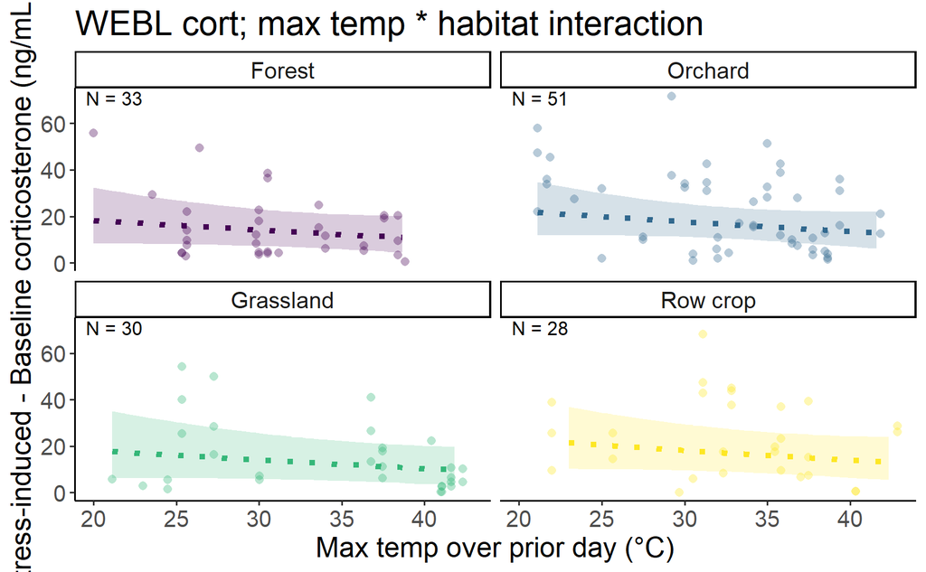

```r
samp <- abs_lintemp_noint@frame %>% group_by(habitat) %>% summarize(count = n())
# samp %>% gt() %>% gtsave("figures/ss_webl_abs_priordayt.html")


dat_text_webl <- data.frame(
  label = paste("N =",samp$count),
  group   = factor(c("Forest","Orchard","Grassland","Row crop"))
)

data_webl_priordayt = dplyr::filter(g,Species == "WEBL",!is.na(maxt_prior),!is.na(mint_prior)) %>%
  mutate(across(c(gweight,maxt_prior,mint_prior,juliandate,brood_size,age),
                ~ scale(.x)[,1],
                .names = "{.col}_scaled"),
         maxt_prior_scaled_sq = maxt_prior_scaled * maxt_prior_scaled)


mean_temp_webl_priordayt <- mean(data_webl_priordayt %>% pull(maxt_prior))
sd_temp_webl_priordayt <- sd(data_webl_priordayt %>% pull(maxt_prior))


temp_trans_webl_priordayt <- trans_new("temp_trans_webl_priordayt",
                             transform = function(x){(x * sd_temp_webl_priordayt) + mean_temp_webl_priordayt},
                             inverse = function(x){x})

(fig4_webl_priordayt <- ggpredict(prior_model,terms = c("maxt_prior_scaled [all]","habitat"),bias_correction = TRUE) %>%
    plot(line_size = 1.5,alpha = .2,show_data = TRUE,limit_range = TRUE) +
    aes(linetype = .data[["group"]]) +
    theme_classic() +
    facet_wrap(~ group, ncol = 2) +
    xlab("Max temp over prior day (\u00b0C)") +
    ylab("Stress-induced - Baseline corticosterone (ng/mL)") +
    scale_fill_viridis(discrete = TRUE) +
    scale_color_viridis(discrete = TRUE) +
    theme(text = element_text(size = 16)) +
    labs(title = "WEBL cort; max temp * habitat interaction") +
    scale_x_continuous(trans = temp_trans_webl_priordayt,
                       breaks = c((20-mean_temp_webl_priordayt)/sd_temp_webl_priordayt,
                                  (25-mean_temp_webl_priordayt)/sd_temp_webl_priordayt,
                                  (30-mean_temp_webl_priordayt)/sd_temp_webl_priordayt,
                                  (35-mean_temp_webl_priordayt)/sd_temp_webl_priordayt,
                                  (40-mean_temp_webl_priordayt)/sd_temp_webl_priordayt),
                       # breaks = c(20,30,40,50),
                       # labels = c("20","30","40","50"),
                       # limits = c((15-mean(g$meanmaxtempI,na.rm = TRUE))/sd(g$meanmaxtempI,na.rm = TRUE),
                       #            (55-mean(g$meanmaxtempI,na.rm = TRUE))/sd(g$meanmaxtempI,na.rm = TRUE))
                       # limits = c(18,5)
    ) +
    scale_linetype_manual(values = c("Forest" = "dotted","Orchard" = "dotted","Grassland" = "dotted","Row crop" = "dotted")) +
    # ylim(0,60) +
    geom_text(data = dat_text_webl, mapping = aes(x = -Inf, y = Inf,label = label),hjust = -.2, vjust = 1.2,inherit.aes = FALSE) +
    theme(legend.position = "none")
)
```

```
G3;Model has sqrt-transformed response. Back-transforming predictions to original response scale. Standard
  errors are still on the transformed scale.
gG3;Data points may overlap. Use the `jitter` argument to add some amount of random variation to the
  location of data points and avoid overplotting.
gScale for colour is already present.
```

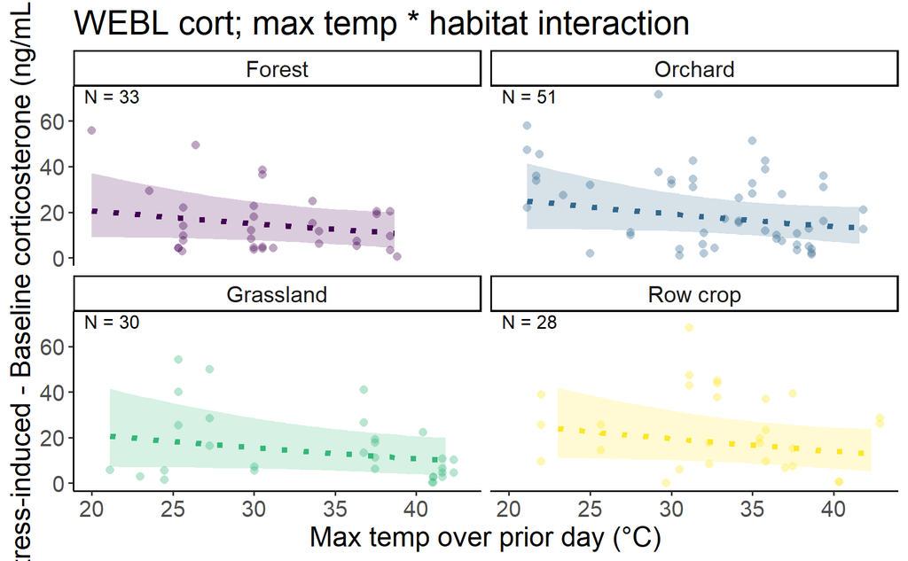

```r
(fig4_webl_priordayt <- ggpredict(abs_lintemp_noint,terms = c("maxt_prior_scaled [all]","habitat"),bias_correction = TRUE) %>%
    plot(line_size = 1.5,alpha = .2,show_data = TRUE,limit_range = TRUE) +
    aes(linetype = .data[["group"]]) +
    theme_classic() +
    facet_wrap(~ group, ncol = 2) +
    xlab("Max temp over prior day (\u00b0C)") +
    ylab("Stress-induced - Baseline corticosterone (ng/mL)") +
    scale_fill_viridis(discrete = TRUE) +
    scale_color_viridis(discrete = TRUE) +
    theme(text = element_text(size = 16)) +
    labs(title = "WEBL cort; max temp * habitat interaction") +
    scale_x_continuous(trans = temp_trans_webl_priordayt,
                       breaks = c((20-mean_temp_webl_priordayt)/sd_temp_webl_priordayt,
                                  (25-mean_temp_webl_priordayt)/sd_temp_webl_priordayt,
                                  (30-mean_temp_webl_priordayt)/sd_temp_webl_priordayt,
                                  (35-mean_temp_webl_priordayt)/sd_temp_webl_priordayt,
                                  (40-mean_temp_webl_priordayt)/sd_temp_webl_priordayt),
                       # breaks = c(20,30,40,50),
                       # labels = c("20","30","40","50"),
                       # limits = c((15-mean(g$meanmaxtempI,na.rm = TRUE))/sd(g$meanmaxtempI,na.rm = TRUE),
                       #            (55-mean(g$meanmaxtempI,na.rm = TRUE))/sd(g$meanmaxtempI,na.rm = TRUE))
                       # limits = c(18,5)
    ) +
    scale_linetype_manual(values = c("Forest" = "dotted","Orchard" = "dotted","Grassland" = "dotted","Row crop" = "dotted")) +
    # ylim(0,60) +
    geom_text(data = dat_text_webl, mapping = aes(x = -Inf, y = Inf,label = label),hjust = -.2, vjust = 1.2,inherit.aes = FALSE) +
    theme(legend.position = "none")
)
```

```
G3;Model has sqrt-transformed response. Back-transforming predictions to original response scale. Standard
  errors are still on the transformed scale.
gG3;Data points may overlap. Use the `jitter` argument to add some amount of random variation to the
  location of data points and avoid overplotting.
g
```

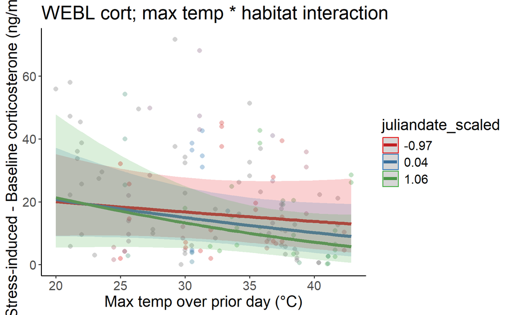

```r
(fig4_webl_priordayt <- ggpredict(abs_lintemp_noint,terms = c("maxt_prior_scaled [all]","juliandate_scaled"),bias_correction = TRUE) %>%
    plot(line_size = 1.5,alpha = .2,show_data = TRUE,limit_range = TRUE) +
    # aes(linetype = .data[["group"]]) +
    theme_classic() +
    # facet_wrap(~ group, ncol = 2) +
    xlab("Max temp over prior day (\u00b0C)") +
    ylab("Stress-induced - Baseline corticosterone (ng/mL)") +
    # scale_fill_viridis(discrete = TRUE) +
    # scale_color_viridis(discrete = TRUE) +
    theme(text = element_text(size = 16)) +
    labs(title = "WEBL cort; max temp * habitat interaction") +
    scale_x_continuous(trans = temp_trans_webl_priordayt,
                       breaks = c((20-mean_temp_webl_priordayt)/sd_temp_webl_priordayt,
                                  (25-mean_temp_webl_priordayt)/sd_temp_webl_priordayt,
                                  (30-mean_temp_webl_priordayt)/sd_temp_webl_priordayt,
                                  (35-mean_temp_webl_priordayt)/sd_temp_webl_priordayt,
                                  (40-mean_temp_webl_priordayt)/sd_temp_webl_priordayt),
                       # breaks = c(20,30,40,50),
                       # labels = c("20","30","40","50"),
                       # limits = c((15-mean(g$meanmaxtempI,na.rm = TRUE))/sd(g$meanmaxtempI,na.rm = TRUE),
                       #            (55-mean(g$meanmaxtempI,na.rm = TRUE))/sd(g$meanmaxtempI,na.rm = TRUE))
                       # limits = c(18,5)
    ) # +
    # scale_linetype_manual(values = c("Forest" = "dotted","Orchard" = "dotted","Grassland" = "dotted","Row crop" = "dotted")) +
    # # ylim(0,60) +
    # geom_text(data = dat_text_webl, mapping = aes(x = -Inf, y = Inf,label = label),hjust = -.2, vjust = 1.2,inherit.aes = FALSE) +
    # theme(legend.position = "none")
)
```

Interaction not significant

#### TRES

```r
prior_model <- lmerTest::lmer(sqrt(abs_change_cort) ~ maxt_prior_scaled * habitat + mint_prior_scaled * habitat + age_scaled + juliandate_scaled + year_fct + (1|attempt_id),data = dplyr::filter(g,Species == "TRES",!is.na(maxt_prior),!is.na(mint_prior)) %>%
                                mutate(across(c(gweight,maxt_prior,mint_prior,juliandate,brood_size,age),
                                              ~ scale(.x)[,1],
                                              .names = "{.col}_scaled"),
                                       maxt_prior_scaled_sq = maxt_prior_scaled * maxt_prior_scaled))

abs_lintemp <- lmerTest::lmer(sqrt(abs_change_cort) ~ maxt_prior_scaled * habitat + mint_prior_scaled * habitat + age_scaled +  maxt_prior_scaled * juliandate_scaled + year_fct + (1|attempt_id),data = dplyr::filter(g,Species == "TRES",!is.na(maxt_prior),!is.na(mint_prior)) %>%
                                mutate(across(c(gweight,maxt_prior,mint_prior,juliandate,brood_size,age),
                                              ~ scale(.x)[,1],
                                              .names = "{.col}_scaled"),
                                       maxt_prior_scaled_sq = maxt_prior_scaled * maxt_prior_scaled))

abs_lintemp_addmax <- lmerTest::lmer(sqrt(abs_change_cort) ~ maxt_prior_scaled + mint_prior_scaled * habitat + age_scaled +  maxt_prior_scaled * juliandate_scaled + year_fct + (1|attempt_id),data = dplyr::filter(g,Species == "TRES",!is.na(maxt_prior),!is.na(mint_prior)) %>%
                                       mutate(across(c(gweight,maxt_prior,mint_prior,juliandate,brood_size,age),
                                                     ~ scale(.x)[,1],
                                                     .names = "{.col}_scaled"),
                                              maxt_prior_scaled_sq = maxt_prior_scaled * maxt_prior_scaled))

abs_lintemp_addmin <- lmerTest::lmer(sqrt(abs_change_cort) ~ maxt_prior_scaled * habitat + mint_prior_scaled + age_scaled +  maxt_prior_scaled * juliandate_scaled + year_fct + (1|attempt_id),data = dplyr::filter(g,Species == "TRES",!is.na(maxt_prior),!is.na(mint_prior)) %>%
                                       mutate(across(c(gweight,maxt_prior,mint_prior,juliandate,brood_size,age),
                                                     ~ scale(.x)[,1],
                                                     .names = "{.col}_scaled"),
                                              maxt_prior_scaled_sq = maxt_prior_scaled * maxt_prior_scaled))

abs_lintemp_noint <- lmerTest::lmer(sqrt(abs_change_cort) ~ maxt_prior_scaled + mint_prior_scaled + habitat + age_scaled +  maxt_prior_scaled * juliandate_scaled + year_fct + (1|attempt_id),data = dplyr::filter(g,Species == "TRES",!is.na(maxt_prior),!is.na(mint_prior)) %>%
                                      mutate(across(c(gweight,maxt_prior,mint_prior,juliandate,brood_size,age),
                                                    ~ scale(.x)[,1],
                                                    .names = "{.col}_scaled"),
                                             maxt_prior_scaled_sq = maxt_prior_scaled * maxt_prior_scaled))

c1 <- anova(abs_lintemp,abs_lintemp_addmin,abs_lintemp_noint) %>% tibble() %>% mutate(Model = c("no interaction","single interaction","both interacting"),.before = npar)
```

```
G3;refitting model(s) with ML (instead of REML)
g
```

```r
c2 <- anova(abs_lintemp,abs_lintemp_addmax,abs_lintemp_noint) %>% tibble() %>% mutate(Model = c("no interaction","single interaction","both interacting"),.before = npar)
```

```
G3;refitting model(s) with ML (instead of REML)
g
```

```r
(int_tab_abs_priordayt_tres <- bind_rows(c1,c2) %>%
    as.tibble() %>%
    mutate(across(where(is.numeric),~round(.x,digits = 3)),
           P = `Pr(>Chisq)`) %>%
    dplyr::select(Model,AIC,Chisq,P) %>%
    mutate(max_or_min = c(rep("Max temp",times = 3),rep("Min temp",times = 3)),
           across(c(AIC,Chisq), ~ round(.x, digits = 2)),
           P = if_else(P < 0.001,"<0.001",as.character(P))) %>%
    group_by(max_or_min) %>% gt())
```

| Model | AIC | Chisq | P |
| --- | --- | --- | --- |
| Max temp |  |  |  |
| no interaction | 349.25 | NA | NA |
| single interaction | 353.87 | 1.38 | 0.711 |
| both interacting | 352.45 | 7.42 | 0.06 |
| Min temp |  |  |  |
| no interaction | 349.25 | NA | NA |
| single interaction | 352.29 | 2.96 | 0.398 |
| both interacting | 352.45 | 5.84 | 0.12 |

```r
# gtsave(int_tab_abs_priordayt_tres,"figures/int_tab_abs_priordayt_tres.html")

check_collinearity(abs_lintemp_noint)
```

```
# Check for Multicollinearity

Low Correlation

                                Term  VIF   VIF 95% CI Increased SE Tolerance Tolerance 95% CI
                   maxt_prior_scaled 2.62 [2.00, 3.64]         1.62      0.38     [0.27, 0.50]
                   mint_prior_scaled 2.00 [1.57, 2.74]         1.41      0.50     [0.36, 0.64]
                             habitat 1.55 [1.27, 2.11]         1.24      0.65     [0.47, 0.79]
                          age_scaled 1.36 [1.15, 1.87]         1.16      0.74     [0.54, 0.87]
                   juliandate_scaled 1.90 [1.50, 2.60]         1.38      0.53     [0.38, 0.67]
                            year_fct 1.68 [1.36, 2.29]         1.30      0.60     [0.44, 0.74]
 maxt_prior_scaled:juliandate_scaled 1.19 [1.05, 1.73]         1.09      0.84     [0.58, 0.95]
```

```r
summary(abs_lintemp)
```

```
Linear mixed model fit by REML. t-tests use Satterthwaite's method ['lmerModLmerTest']
Formula: sqrt(abs_change_cort) ~ maxt_prior_scaled * habitat + mint_prior_scaled *
    habitat + age_scaled + maxt_prior_scaled * juliandate_scaled +      year_fct + (1 | attempt_id)
   Data: dplyr::filter(g, Species == "TRES", !is.na(maxt_prior), !is.na(mint_prior)) %>%
    mutate(across(c(gweight, maxt_prior, mint_prior, juliandate,
        brood_size, age), ~scale(.x)[, 1], .names = "{.col}_scaled"),
        maxt_prior_scaled_sq = maxt_prior_scaled * maxt_prior_scaled)

REML criterion at convergence: 304.6

Scaled residuals:
     Min       1Q   Median       3Q      Max
-2.07743 -0.43764 -0.00556  0.53431  1.99129

Random effects:
 Groups     Name        Variance Std.Dev.
 attempt_id (Intercept) 1.215    1.102
 Residual               2.994    1.730
Number of obs: 80, groups:  attempt_id, 38

Fixed effects:
                                    Estimate Std. Error       df t value Pr(>|t|)
(Intercept)                          5.16450    2.02600 21.92854   2.549   0.0183 *
maxt_prior_scaled                   -0.07147    1.62636 17.57261  -0.044   0.9654
habitatOrchard                      -0.29006    2.14818 23.17499  -0.135   0.8938
habitatGrassland                     0.13940    1.96667 21.86326   0.071   0.9441
habitatRow crop                      0.93403    1.99773 21.93510   0.468   0.6447
mint_prior_scaled                    1.25545    1.69406 23.45415   0.741   0.4660
age_scaled                           0.19805    0.47777 29.16734   0.415   0.6815
juliandate_scaled                   -0.14298    0.37381 19.77735  -0.382   0.7062
year_fct2023                         0.33738    0.78188 19.90464   0.431   0.6707
maxt_prior_scaled:habitatOrchard    -3.37972    2.70386 23.13891  -1.250   0.2238
maxt_prior_scaled:habitatGrassland   0.53060    1.75470 17.95375   0.302   0.7658
maxt_prior_scaled:habitatRow crop    0.82721    1.63217 17.08809   0.507   0.6188
habitatOrchard:mint_prior_scaled    -5.42777    3.16203 34.39238  -1.717   0.0951 .
habitatGrassland:mint_prior_scaled  -0.86422    1.72879 22.17413  -0.500   0.6221
habitatRow crop:mint_prior_scaled   -1.94181    1.84017 21.79424  -1.055   0.3029
maxt_prior_scaled:juliandate_scaled -0.03498    0.41319 26.72488  -0.085   0.9332
---
Signif. codes:  0 '***' 0.001 '**' 0.01 '*' 0.05 '.' 0.1 ' ' 1
```

```
G3;
Correlation matrix not shown by default, as p = 16 > 12.
Use print(x, correlation=TRUE)  or
    vcov(x)        if you need it

g
```

```r
abs_tres_priordayt <- abs_lintemp

anova(abs_lintemp,prior_model)
```

```
G3;refitting model(s) with ML (instead of REML)
g
```

```
Data: dplyr::filter(g, Species == "TRES", !is.na(maxt_prior), !is.na(mint_prior)) %>%  ...
Models:
prior_model: sqrt(abs_change_cort) ~ maxt_prior_scaled * habitat + mint_prior_scaled * habitat + age_scaled + juliandate_scaled + year_fct + (1 | attempt_id)
abs_lintemp: sqrt(abs_change_cort) ~ maxt_prior_scaled * habitat + mint_prior_scaled * habitat + age_scaled + maxt_prior_scaled * juliandate_scaled + year_fct + (1 | attempt_id)
            npar    AIC    BIC  logLik deviance  Chisq Df Pr(>Chisq)
prior_model   17 350.45 390.95 -158.23   316.45
abs_lintemp   18 352.45 395.33 -158.23   316.45 0.0017  1     0.9667
```

Interaction not significant, does not improve fit, does not change parsimony

```r
(tresabs_priordayt_trendmax_prior <- emtrends(prior_model,specs = ~ habitat, var = c("maxt_prior_scaled")) %>% test() %>%
    mutate(across(where(is.numeric), ~ round(.x, digits = 3)),
           df = round(df),
           p.value = if_else(p.value == 0.000,"<0.001",as.character(p.value))) %>%
    rename(Habitat = "habitat", `Max temp trend` = "maxt_prior_scaled.trend",Df = "df", `T-ratio` = "t.ratio", P = "p.value") %>%
    gt())
```

| Habitat | Max temp trend | SE | Df | T-ratio | P |
| --- | --- | --- | --- | --- | --- |
| Forest | -0.055 | 1.587 | 19 | -0.035 | 0.973 |
| Orchard | -3.431 | 2.218 | 28 | -1.546 | 0.133 |
| Grassland | 0.441 | 0.719 | 25 | 0.613 | 0.546 |
| Row crop | 0.767 | 0.617 | 21 | 1.245 | 0.227 |

```r
(tresabs_priordayt_trendmax <- emtrends(abs_lintemp,specs = ~ habitat, var = c("maxt_prior_scaled")) %>% test() %>%
    mutate(across(where(is.numeric), ~ round(.x, digits = 3)),
           df = round(df),
           p.value = if_else(p.value == 0.000,"<0.001",as.character(p.value))) %>%
    rename(Habitat = "habitat", `Max temp trend` = "maxt_prior_scaled.trend",Df = "df", `T-ratio` = "t.ratio", P = "p.value") %>%
    gt())
```

| Habitat | Max temp trend | SE | Df | T-ratio | P |
| --- | --- | --- | --- | --- | --- |
| Forest | -0.082 | 1.654 | 18 | -0.049 | 0.961 |
| Orchard | -3.461 | 2.320 | 27 | -1.492 | 0.148 |
| Grassland | 0.449 | 0.740 | 25 | 0.607 | 0.55 |
| Row crop | 0.746 | 0.653 | 20 | 1.142 | 0.267 |

Same trend and non significance

```
G3;Model has sqrt-transformed response. Back-transforming predictions to original response scale. Standard
  errors are still on the transformed scale.
gG3;Data points may overlap. Use the `jitter` argument to add some amount of random variation to the
  location of data points and avoid overplotting.
gScale for colour is already present.
```

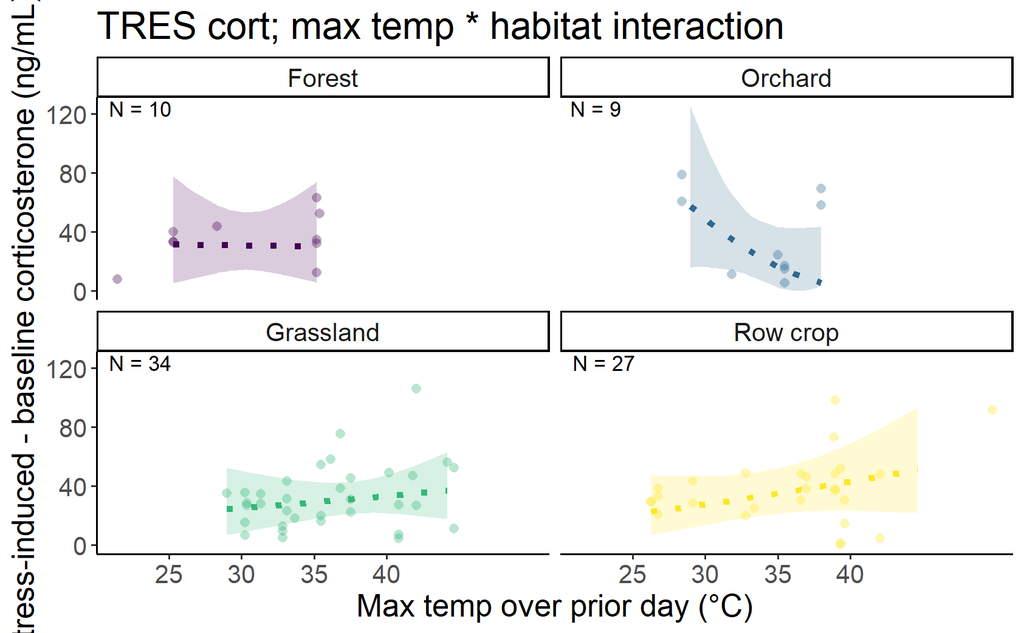

```r
samp <- abs_lintemp@frame %>% group_by(habitat) %>% summarize(count = n())
# samp %>% gt() %>% gtsave("figures/ss_tres_abs_priordayt.html")


dat_text_tres <- data.frame(
  label = paste("N =",samp$count),
  group   = factor(c("Forest","Orchard","Grassland","Row crop"))
)

data_tres_priordayt = dplyr::filter(g,Species == "TRES",!is.na(maxt_prior),!is.na(mint_prior)) %>%
  mutate(across(c(gweight,maxt_prior,mint_prior,juliandate,brood_size,age),
                ~ scale(.x)[,1],
                .names = "{.col}_scaled"),
         maxt_prior_scaled_sq = maxt_prior_scaled * maxt_prior_scaled)


mean_temp_tres_priordayt <- mean(data_tres_priordayt %>% pull(maxt_prior))
sd_temp_tres_priordayt <- sd(data_tres_priordayt %>% pull(maxt_prior))


temp_trans_tres_priordayt <- trans_new("temp_trans_tres_priordayt",
                                       transform = function(x){(x * sd_temp_tres_priordayt) + mean_temp_tres_priordayt},
                                       inverse = function(x){x})

(fig4_tres_priordayt <- ggpredict(prior_model,terms = c("maxt_prior_scaled [all]","habitat"),bias_correction = TRUE) %>%
    plot(line_size = 1.5,alpha = .2,show_data = TRUE,limit_range = TRUE) +
    aes(linetype = .data[["group"]]) +
    theme_classic() +
    facet_wrap(~ group, ncol = 2) +
    xlab("Max temp over prior day (\u00b0C)") +
    ylab("Stress-induced - baseline corticosterone (ng/mL)") +
    scale_fill_viridis(discrete = TRUE) +
    scale_color_viridis(discrete = TRUE) +
    theme(text = element_text(size = 16)) +
    labs(title = "TRES cort; max temp * habitat interaction") +
    scale_x_continuous(trans = temp_trans_tres_priordayt,
                       breaks = c((20-mean_temp_tres_priordayt)/sd_temp_tres_priordayt,
                                  (25-mean_temp_tres_priordayt)/sd_temp_tres_priordayt,
                                  (30-mean_temp_tres_priordayt)/sd_temp_tres_priordayt,
                                  (35-mean_temp_tres_priordayt)/sd_temp_tres_priordayt,
                                  (40-mean_temp_tres_priordayt)/sd_temp_tres_priordayt),
                       # breaks = c(20,30,40,50),
                       # labels = c("20","30","40","50"),
                       # limits = c((15-mean(g$meanmaxtempI,na.rm = TRUE))/sd(g$meanmaxtempI,na.rm = TRUE),
                       #            (55-mean(g$meanmaxtempI,na.rm = TRUE))/sd(g$meanmaxtempI,na.rm = TRUE))
                       # limits = c(18,5)
    ) +
    scale_linetype_manual(values = c("Forest" = "dotted","Orchard" = "dotted","Grassland" = "dotted","Row crop" = "dotted")) +
    # ylim(0,60) +
    geom_text(data = dat_text_tres, mapping = aes(x = -Inf, y = Inf,label = label),hjust = -.2, vjust = 1.2,inherit.aes = FALSE) +
    theme(legend.position = "none")
)
```

```
G3;Model has sqrt-transformed response. Back-transforming predictions to original response scale. Standard
  errors are still on the transformed scale.
gG3;Data points may overlap. Use the `jitter` argument to add some amount of random variation to the
  location of data points and avoid overplotting.
gScale for colour is already present.
```

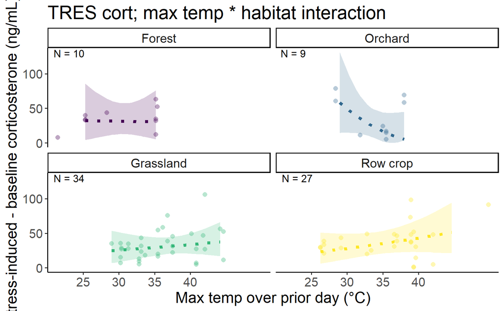

```r
(fig4_tres_priordayt <- ggpredict(abs_lintemp,terms = c("maxt_prior_scaled [all]","habitat"),bias_correction = TRUE) %>%
    plot(line_size = 1.5,alpha = .2,show_data = TRUE,limit_range = TRUE) +
    aes(linetype = .data[["group"]]) +
    theme_classic() +
    facet_wrap(~ group, ncol = 2) +
    xlab("Max temp over prior day (\u00b0C)") +
    ylab("Stress-induced - baseline corticosterone (ng/mL)") +
    scale_fill_viridis(discrete = TRUE) +
    scale_color_viridis(discrete = TRUE) +
    theme(text = element_text(size = 16)) +
    labs(title = "TRES cort; max temp * habitat interaction") +
    scale_x_continuous(trans = temp_trans_tres_priordayt,
                       breaks = c((20-mean_temp_tres_priordayt)/sd_temp_tres_priordayt,
                                  (25-mean_temp_tres_priordayt)/sd_temp_tres_priordayt,
                                  (30-mean_temp_tres_priordayt)/sd_temp_tres_priordayt,
                                  (35-mean_temp_tres_priordayt)/sd_temp_tres_priordayt,
                                  (40-mean_temp_tres_priordayt)/sd_temp_tres_priordayt),
                       # breaks = c(20,30,40,50),
                       # labels = c("20","30","40","50"),
                       # limits = c((15-mean(g$meanmaxtempI,na.rm = TRUE))/sd(g$meanmaxtempI,na.rm = TRUE),
                       #            (55-mean(g$meanmaxtempI,na.rm = TRUE))/sd(g$meanmaxtempI,na.rm = TRUE))
                       # limits = c(18,5)
    ) +
    scale_linetype_manual(values = c("Forest" = "dotted","Orchard" = "dotted","Grassland" = "dotted","Row crop" = "dotted")) +
    # ylim(0,60) +
    geom_text(data = dat_text_tres, mapping = aes(x = -Inf, y = Inf,label = label),hjust = -.2, vjust = 1.2,inherit.aes = FALSE) +
    theme(legend.position = "none")
)
```

```
G3;Model has sqrt-transformed response. Back-transforming predictions to original response scale. Standard
  errors are still on the transformed scale.
gG3;Data points may overlap. Use the `jitter` argument to add some amount of random variation to the
  location of data points and avoid overplotting.
g
```

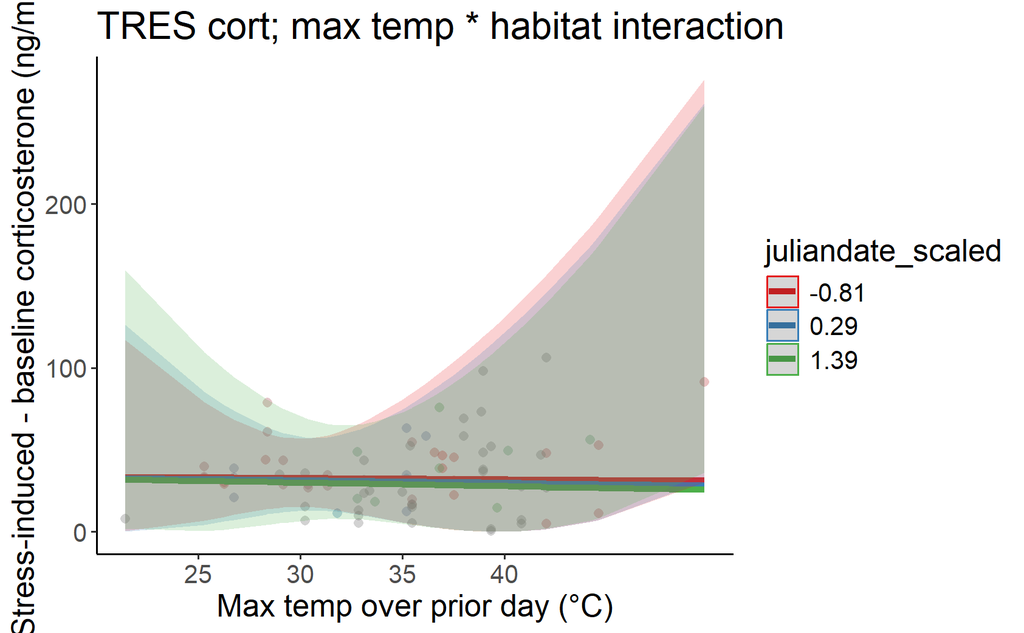

```r
(fig4_tres_priordayt <- ggpredict(abs_lintemp,terms = c("maxt_prior_scaled [all]","juliandate_scaled"),bias_correction = TRUE) %>%
    plot(line_size = 1.5,alpha = .2,show_data = TRUE,limit_range = TRUE) +
    # aes(linetype = .data[["group"]]) +
    theme_classic() +
    # facet_wrap(~ group, ncol = 2) +
    xlab("Max temp over prior day (\u00b0C)") +
    ylab("Stress-induced - baseline corticosterone (ng/mL)") +
    # scale_fill_viridis(discrete = TRUE) +
    # scale_color_viridis(discrete = TRUE) +
    theme(text = element_text(size = 16)) +
    labs(title = "TRES cort; max temp * habitat interaction") +
    scale_x_continuous(trans = temp_trans_tres_priordayt,
                       breaks = c((20-mean_temp_tres_priordayt)/sd_temp_tres_priordayt,
                                  (25-mean_temp_tres_priordayt)/sd_temp_tres_priordayt,
                                  (30-mean_temp_tres_priordayt)/sd_temp_tres_priordayt,
                                  (35-mean_temp_tres_priordayt)/sd_temp_tres_priordayt,
                                  (40-mean_temp_tres_priordayt)/sd_temp_tres_priordayt),
                       # breaks = c(20,30,40,50),
                       # labels = c("20","30","40","50"),
                       # limits = c((15-mean(g$meanmaxtempI,na.rm = TRUE))/sd(g$meanmaxtempI,na.rm = TRUE),
                       #            (55-mean(g$meanmaxtempI,na.rm = TRUE))/sd(g$meanmaxtempI,na.rm = TRUE))
                       # limits = c(18,5)
    ) # +
    # scale_linetype_manual(values = c("Forest" = "dotted","Orchard" = "solid","Grassland" = "dotted","Row crop" = "dotted")) +
    # # ylim(0,60) +
    # geom_text(data = dat_text_tres, mapping = aes(x = -Inf, y = Inf,label = label),hjust = -.2, vjust = 1.2,inherit.aes = FALSE) +
    # theme(legend.position = "none")
)
```

Interaction is not significant

### s2 cort by prior day temp

#### WEBL

```r
prior_model <- lmerTest::lmer(sqrt(cort_s2) ~ maxt_prior_scaled + mint_prior_scaled + habitat + age_scaled + juliandate_scaled + year_fct + (1|attempt_id),data = dplyr::filter(g,Species == "WEBL",!is.na(maxt_prior),!is.na(mint_prior)) %>%
                                     mutate(across(c(gweight,maxt_prior,mint_prior,juliandate,brood_size,age),
                                                   ~ scale(.x)[,1],
                                                   .names = "{.col}_scaled"),
                                            maxt_prior_scaled_sq = maxt_prior_scaled * maxt_prior_scaled))

s2_lintemp <- lmerTest::lmer(sqrt(cort_s2) ~ maxt_prior_scaled * habitat + mint_prior_scaled * habitat + age_scaled + maxt_prior_scaled * juliandate_scaled + year_fct + (1|attempt_id),data = dplyr::filter(g,Species == "WEBL",!is.na(maxt_prior),!is.na(mint_prior)) %>%
                               mutate(across(c(gweight,maxt_prior,mint_prior,juliandate,brood_size,age),
                                             ~ scale(.x)[,1],
                                             .names = "{.col}_scaled"),
                                      maxt_prior_scaled_sq = maxt_prior_scaled * maxt_prior_scaled))

s2_lintemp_addmax <- lmerTest::lmer(sqrt(cort_s2) ~ maxt_prior_scaled + mint_prior_scaled * habitat + age_scaled + maxt_prior_scaled * juliandate_scaled + year_fct + (1|attempt_id),data = dplyr::filter(g,Species == "WEBL",!is.na(maxt_prior),!is.na(mint_prior)) %>%
                                      mutate(across(c(gweight,maxt_prior,mint_prior,juliandate,brood_size,age),
                                                    ~ scale(.x)[,1],
                                                    .names = "{.col}_scaled"),
                                             maxt_prior_scaled_sq = maxt_prior_scaled * maxt_prior_scaled))

s2_lintemp_addmin <- lmerTest::lmer(sqrt(cort_s2) ~ maxt_prior_scaled * habitat + mint_prior_scaled + age_scaled + maxt_prior_scaled * juliandate_scaled + year_fct + (1|attempt_id),data = dplyr::filter(g,Species == "WEBL",!is.na(maxt_prior),!is.na(mint_prior)) %>%
                                      mutate(across(c(gweight,maxt_prior,mint_prior,juliandate,brood_size,age),
                                                    ~ scale(.x)[,1],
                                                    .names = "{.col}_scaled"),
                                             maxt_prior_scaled_sq = maxt_prior_scaled * maxt_prior_scaled))

s2_lintemp_noint <- lmerTest::lmer(sqrt(cort_s2) ~ maxt_prior_scaled + mint_prior_scaled + habitat + age_scaled + maxt_prior_scaled * juliandate_scaled + year_fct + (1|attempt_id),data = dplyr::filter(g,Species == "WEBL",!is.na(maxt_prior),!is.na(mint_prior)) %>%
                                     mutate(across(c(gweight,maxt_prior,mint_prior,juliandate,brood_size,age),
                                                   ~ scale(.x)[,1],
                                                   .names = "{.col}_scaled"),
                                            maxt_prior_scaled_sq = maxt_prior_scaled * maxt_prior_scaled))

c1 <- anova(s2_lintemp,s2_lintemp_addmin,s2_lintemp_noint) %>% tibble() %>% mutate(Model = c("no interaction","single interaction","both interacting"),.before = npar)
```

```
G3;refitting model(s) with ML (instead of REML)
g
```

```r
c2 <- anova(s2_lintemp,s2_lintemp_addmax,s2_lintemp_noint) %>% tibble() %>% mutate(Model = c("no interaction","single interaction","both interacting"),.before = npar)
```

```
G3;refitting model(s) with ML (instead of REML)
g
```

```r
(int_tab_s2_priordayt_webl <- bind_rows(c1,c2) %>%
    as.tibble() %>%
    mutate(across(where(is.numeric),~round(.x,digits = 3)),
           P = `Pr(>Chisq)`) %>%
    dplyr::select(Model,AIC,Chisq,P) %>%
    mutate(max_or_min = c(rep("Max temp",times = 3),rep("Min temp",times = 3)),
           across(c(AIC,Chisq), ~ round(.x, digits = 2)),
           P = if_else(P < 0.001,"<0.001",as.character(P))) %>%
    group_by(max_or_min) %>% gt())
```

| Model | AIC | Chisq | P |
| --- | --- | --- | --- |
| Max temp |  |  |  |
| no interaction | 597.75 | NA | NA |
| single interaction | 603.60 | 0.15 | 0.985 |
| both interacting | 607.68 | 1.92 | 0.589 |
| Min temp |  |  |  |
| no interaction | 597.75 | NA | NA |
| single interaction | 602.76 | 0.99 | 0.803 |
| both interacting | 607.68 | 1.08 | 0.783 |

```r
# gtsave(int_tab_s2_priordayt_webl,"figures/int_tab_s2_priordayt_webl.html")

s2_prior_day_webl <- s2_lintemp_noint

summary(s2_lintemp_noint)
```

```
Linear mixed model fit by REML. t-tests use Satterthwaite's method ['lmerModLmerTest']
Formula: sqrt(cort_s2) ~ maxt_prior_scaled + mint_prior_scaled + habitat +
    age_scaled + maxt_prior_scaled * juliandate_scaled + year_fct +      (1 | attempt_id)
   Data: dplyr::filter(g, Species == "WEBL", !is.na(maxt_prior), !is.na(mint_prior)) %>%
    mutate(across(c(gweight, maxt_prior, mint_prior, juliandate,
        brood_size, age), ~scale(.x)[, 1], .names = "{.col}_scaled"),
        maxt_prior_scaled_sq = maxt_prior_scaled * maxt_prior_scaled)

REML criterion at convergence: 582.8

Scaled residuals:
     Min       1Q   Median       3Q      Max
-2.54090 -0.53812 -0.03287  0.53650  2.58382

Random effects:
 Groups     Name        Variance Std.Dev.
 attempt_id (Intercept) 1.515    1.231
 Residual               1.379    1.174
Number of obs: 162, groups:  attempt_id, 53

Fixed effects:
                                     Estimate Std. Error        df t value Pr(>|t|)
(Intercept)                           4.16591    0.45077  41.86016   9.242 1.16e-11 ***
maxt_prior_scaled                    -0.03670    0.21003 131.48324  -0.175    0.862
mint_prior_scaled                    -0.05280    0.20077 122.85650  -0.263    0.793
habitatOrchard                        0.59054    0.55254  40.33891   1.069    0.292
habitatGrassland                      0.22096    0.64588  42.67041   0.342    0.734
habitatRow crop                       0.84404    0.61049  39.20813   1.383    0.175
age_scaled                            0.19688    0.12714 148.83841   1.549    0.124
juliandate_scaled                    -0.35971    0.23905  52.93454  -1.505    0.138
year_fct2023                          0.07127    0.47759  43.74986   0.149    0.882
maxt_prior_scaled:juliandate_scaled   0.04792    0.16340 123.11599   0.293    0.770
---
Signif. codes:  0 '***' 0.001 '**' 0.01 '*' 0.05 '.' 0.1 ' ' 1

Correlation of Fixed Effects:
            (Intr) mxt_p_ mnt_p_ hbttOr hbttGr hbttRc ag_scl jlndt_ y_2023
mxt_prr_scl  0.050
mnt_prr_scl  0.011 -0.366
habttOrchrd -0.723 -0.105 -0.137
hbttGrsslnd -0.565 -0.267  0.253  0.476
habittRwcrp -0.626 -0.195  0.027  0.541  0.479
age_scaled   0.034  0.163  0.138 -0.137 -0.024 -0.145
julndt_scld  0.036 -0.371 -0.249  0.090 -0.068  0.111 -0.294
yer_fct2023 -0.321  0.319 -0.223  0.065 -0.168 -0.084  0.097 -0.215
mxt_prr_s:_ -0.181  0.338  0.094 -0.105 -0.105 -0.074  0.124 -0.217  0.217
```

```r
anova(s2_lintemp_noint,prior_model)
```

```
G3;refitting model(s) with ML (instead of REML)
g
```

```
Data: dplyr::filter(g, Species == "WEBL", !is.na(maxt_prior), !is.na(mint_prior)) %>%  ...
Models:
prior_model: sqrt(cort_s2) ~ maxt_prior_scaled + mint_prior_scaled + habitat + age_scaled + juliandate_scaled + year_fct + (1 | attempt_id)
s2_lintemp_noint: sqrt(cort_s2) ~ maxt_prior_scaled + mint_prior_scaled + habitat + age_scaled + maxt_prior_scaled * juliandate_scaled + year_fct + (1 | attempt_id)
                 npar    AIC    BIC  logLik deviance  Chisq Df Pr(>Chisq)
prior_model        11 595.85 629.82 -286.93   573.85
s2_lintemp_noint   12 597.75 634.80 -286.88   573.75 0.1013  1     0.7503
```

Not significant, does not improve fit, does not change parsimony

```r
(webls2_priordayt_trendmax_prior <- emtrends(prior_model,specs = ~ habitat, var = c("maxt_prior_scaled")) %>% test() %>%
    mutate(across(where(is.numeric), ~ round(.x, digits = 3)),
           df = round(df),
           p.value = if_else(p.value == 0.000,"<0.001",as.character(p.value))) %>%
    rename(Habitat = "habitat", `Max temp trend` = "maxt_prior_scaled.trend",Df = "df", `T-ratio` = "t.ratio", P = "p.value") %>%
    gt())
```

| Habitat | Max temp trend | SE | Df | T-ratio | P |
| --- | --- | --- | --- | --- | --- |
| Forest | -0.058 | 0.2 | 139 | -0.288 | 0.774 |
| Orchard | -0.058 | 0.2 | 139 | -0.288 | 0.774 |
| Grassland | -0.058 | 0.2 | 139 | -0.288 | 0.774 |
| Row crop | -0.058 | 0.2 | 139 | -0.288 | 0.774 |

```r
(webls2_priordayt_trendmax <- emtrends(s2_lintemp_noint,specs = ~ habitat, var = c("maxt_prior_scaled")) %>% test() %>%
    mutate(across(where(is.numeric), ~ round(.x, digits = 3)),
           df = round(df),
           p.value = if_else(p.value == 0.000,"<0.001",as.character(p.value))) %>%
    rename(Habitat = "habitat", `Max temp trend` = "maxt_prior_scaled.trend",Df = "df", `T-ratio` = "t.ratio", P = "p.value") %>%
    gt())
```

| Habitat | Max temp trend | SE | Df | T-ratio | P |
| --- | --- | --- | --- | --- | --- |
| Forest | -0.034 | 0.217 | 134 | -0.155 | 0.877 |
| Orchard | -0.034 | 0.217 | 134 | -0.155 | 0.877 |
| Grassland | -0.034 | 0.217 | 134 | -0.155 | 0.877 |
| Row crop | -0.034 | 0.217 | 134 | -0.155 | 0.877 |

Changes nothing

```
G3;Model has sqrt-transformed response. Back-transforming predictions to original response scale. Standard
  errors are still on the transformed scale.
gG3;Data points may overlap. Use the `jitter` argument to add some amount of random variation to the
  location of data points and avoid overplotting.
gScale for colour is already present.
```

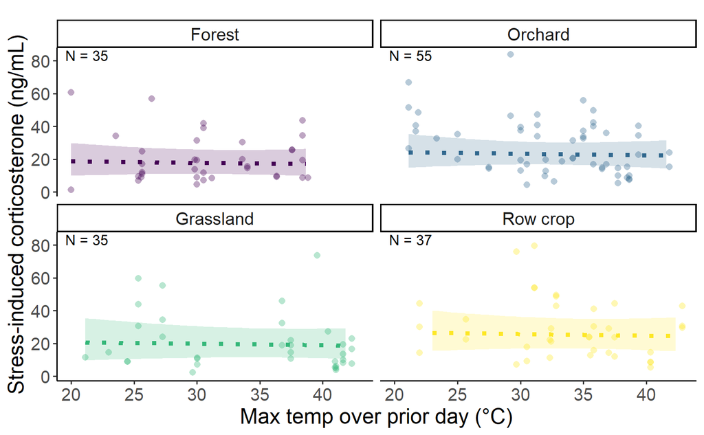

```r
samp_s2_priordayt_webl <- s2_lintemp_noint@frame %>% group_by(habitat) %>% summarize(count = n())
# samp_s2_priordayt_webl %>% gt() %>% gtsave("figures/ss_webl_s2_priordayt_.html")


dat_text_s2_priordayt_webl <- data.frame(
  label = paste("N =",samp_s2_priordayt_webl$count),
  group   = factor(c("Forest","Orchard","Grassland","Row crop"))
)





data_s2_priordayt_webl = dplyr::filter(g,Species == "WEBL",!is.na(maxt_prior),!is.na(mint_prior)) %>%
  mutate(across(c(gweight,maxt_prior,mint_prior,juliandate,brood_size,age),
                ~ scale(.x)[,1],
                .names = "{.col}_scaled"),
         maxt_prior_scaled_sq = maxt_prior_scaled * maxt_prior_scaled)


mean_temp_s2_priordayt_webl <- mean(data_s2_priordayt_webl %>% pull(maxt_prior))
sd_temp_s2_priordayt_webl <- sd(data_s2_priordayt_webl %>% pull(maxt_prior))


temp_trans_s2_priordayt_webl <- trans_new("temp_trans_s2_priordayt_webl",
                                          transform = function(x){(x * sd_temp_s2_priordayt_webl) + mean_temp_s2_priordayt_webl},
                                          inverse = function(x){x})

(fig_priordayt_webl_s2 <- ggpredict(prior_model,terms = c("maxt_prior_scaled [all]","habitat"),bias_correction = TRUE) %>%
    plot(line_size = 1.5,alpha = .2,show_data = TRUE,limit_range = TRUE) +
    aes(linetype = .data[["group"]]) +
    theme_classic() +
    facet_wrap(~ group, ncol = 2) +
    xlab("Max temp over prior day (\u00b0C)") +
    ylab("Stress-induced corticosterone (ng/mL)") +
    scale_fill_viridis(discrete = TRUE) +
    scale_color_viridis(discrete = TRUE) +
    theme(text = element_text(size = 16)) +
    labs(title = element_blank()) +
    scale_x_continuous(trans = temp_trans_s2_priordayt_webl,
                       breaks = c((20-mean_temp_s2_priordayt_webl)/sd_temp_s2_priordayt_webl,
                                  (25-mean_temp_s2_priordayt_webl)/sd_temp_s2_priordayt_webl,
                                  (30-mean_temp_s2_priordayt_webl)/sd_temp_s2_priordayt_webl,
                                  (35-mean_temp_s2_priordayt_webl)/sd_temp_s2_priordayt_webl,
                                  (40-mean_temp_s2_priordayt_webl)/sd_temp_s2_priordayt_webl),
                       # breaks = c(20,30,40,50),
                       # labels = c("20","30","40","50"),
                       # limits = c((15-mean(g$meanmaxtempI,na.rm = TRUE))/sd(g$meanmaxtempI,na.rm = TRUE),
                       #            (55-mean(g$meanmaxtempI,na.rm = TRUE))/sd(g$meanmaxtempI,na.rm = TRUE))
                       # limits = c(18,5)
    ) +
    scale_linetype_manual(values = c("dotted","dotted","dotted","dotted")) +
    #ylim(-5,5) +
    geom_text(data = dat_text_s2_priordayt_webl, mapping = aes(x = -Inf, y = Inf,label = label),hjust = -.2, vjust = 1.2,inherit.aes = FALSE) +
    theme(legend.position = "none")
)
```

```
G3;Model has sqrt-transformed response. Back-transforming predictions to original response scale. Standard
  errors are still on the transformed scale.
gG3;Data points may overlap. Use the `jitter` argument to add some amount of random variation to the
  location of data points and avoid overplotting.
gScale for colour is already present.
```

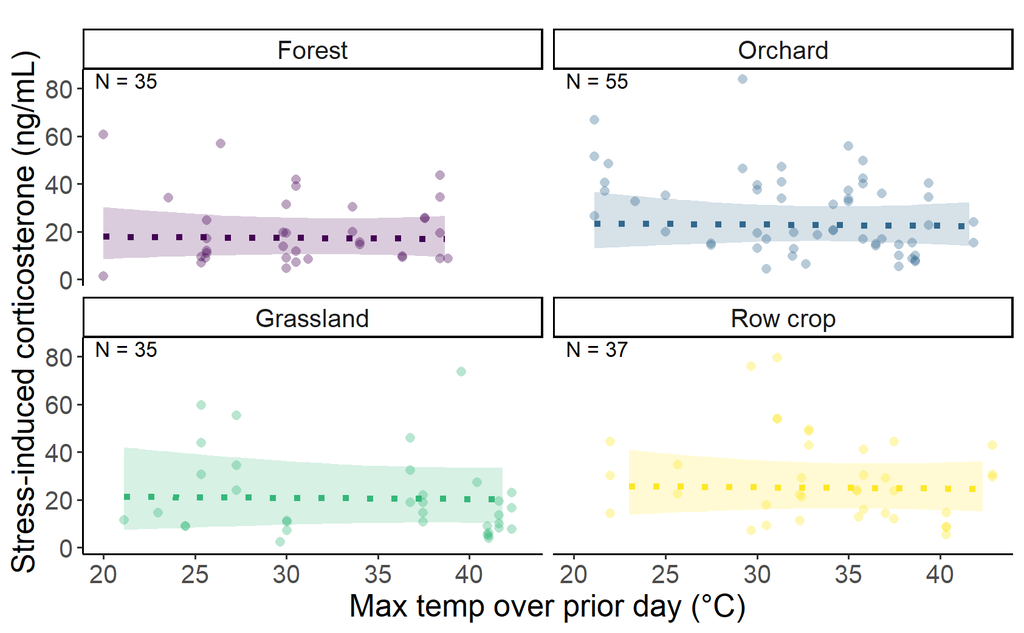

```r
(fig_priordayt_webl_s2 <- ggpredict(s2_lintemp_addmax,terms = c("maxt_prior_scaled [all]","habitat"),bias_correction = TRUE) %>%
    plot(line_size = 1.5,alpha = .2,show_data = TRUE,limit_range = TRUE) +
    aes(linetype = .data[["group"]]) +
    theme_classic() +
    facet_wrap(~ group, ncol = 2) +
    xlab("Max temp over prior day (\u00b0C)") +
    ylab("Stress-induced corticosterone (ng/mL)") +
    scale_fill_viridis(discrete = TRUE) +
    scale_color_viridis(discrete = TRUE) +
    theme(text = element_text(size = 16)) +
    labs(title = element_blank()) +
    scale_x_continuous(trans = temp_trans_s2_priordayt_webl,
                       breaks = c((20-mean_temp_s2_priordayt_webl)/sd_temp_s2_priordayt_webl,
                                  (25-mean_temp_s2_priordayt_webl)/sd_temp_s2_priordayt_webl,
                                  (30-mean_temp_s2_priordayt_webl)/sd_temp_s2_priordayt_webl,
                                  (35-mean_temp_s2_priordayt_webl)/sd_temp_s2_priordayt_webl,
                                  (40-mean_temp_s2_priordayt_webl)/sd_temp_s2_priordayt_webl),
                       # breaks = c(20,30,40,50),
                       # labels = c("20","30","40","50"),
                       # limits = c((15-mean(g$meanmaxtempI,na.rm = TRUE))/sd(g$meanmaxtempI,na.rm = TRUE),
                       #            (55-mean(g$meanmaxtempI,na.rm = TRUE))/sd(g$meanmaxtempI,na.rm = TRUE))
                       # limits = c(18,5)
    ) +
    scale_linetype_manual(values = c("dotted","dotted","dotted","dotted")) +
    #ylim(-5,5) +
    geom_text(data = dat_text_s2_priordayt_webl, mapping = aes(x = -Inf, y = Inf,label = label),hjust = -.2, vjust = 1.2,inherit.aes = FALSE) +
    theme(legend.position = "none")
)
```

```
G3;Model has sqrt-transformed response. Back-transforming predictions to original response scale. Standard
  errors are still on the transformed scale.
gG3;Data points may overlap. Use the `jitter` argument to add some amount of random variation to the
  location of data points and avoid overplotting.
g
```

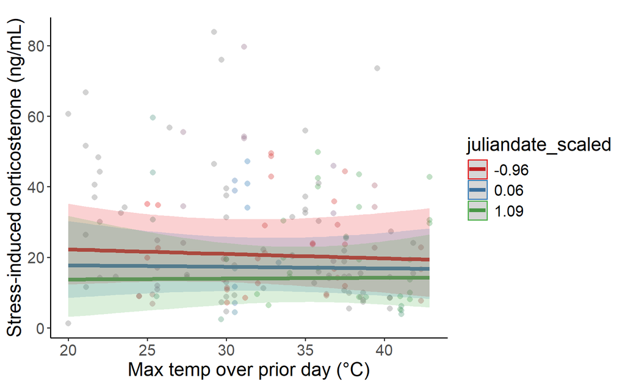

```r
(fig_priordayt_webl_s2 <- ggpredict(s2_lintemp_addmax,terms = c("maxt_prior_scaled [all]","juliandate_scaled"),bias_correction = TRUE) %>%
    plot(line_size = 1.5,alpha = .2,show_data = TRUE,limit_range = TRUE) +
    # aes(linetype = .data[["group"]]) +
    theme_classic() +
    # facet_wrap(~ group, ncol = 2) +
    xlab("Max temp over prior day (\u00b0C)") +
    ylab("Stress-induced corticosterone (ng/mL)") +
    # scale_fill_viridis(discrete = TRUE) +
    # scale_color_viridis(discrete = TRUE) +
    theme(text = element_text(size = 16)) +
    labs(title = element_blank()) +
    scale_x_continuous(trans = temp_trans_s2_priordayt_webl,
                       breaks = c((20-mean_temp_s2_priordayt_webl)/sd_temp_s2_priordayt_webl,
                                  (25-mean_temp_s2_priordayt_webl)/sd_temp_s2_priordayt_webl,
                                  (30-mean_temp_s2_priordayt_webl)/sd_temp_s2_priordayt_webl,
                                  (35-mean_temp_s2_priordayt_webl)/sd_temp_s2_priordayt_webl,
                                  (40-mean_temp_s2_priordayt_webl)/sd_temp_s2_priordayt_webl),
                       # breaks = c(20,30,40,50),
                       # labels = c("20","30","40","50"),
                       # limits = c((15-mean(g$meanmaxtempI,na.rm = TRUE))/sd(g$meanmaxtempI,na.rm = TRUE),
                       #            (55-mean(g$meanmaxtempI,na.rm = TRUE))/sd(g$meanmaxtempI,na.rm = TRUE))
                       # limits = c(18,5)
    ) # +
    # scale_linetype_manual(values = c("dotted","dotted","dotted","dotted")) +
    # #ylim(-5,5) +
    # geom_text(data = dat_text_s2_priordayt_webl, mapping = aes(x = -Inf, y = Inf,label = label),hjust = -.2, vjust = 1.2,inherit.aes = FALSE) +
    # theme(legend.position = "none")
)
```

No interaction

#### TRES

```r
prior_model <- lmerTest::lmer(sqrt(cort_s2) ~ maxt_prior_scaled * habitat + mint_prior_scaled * habitat + age_scaled + juliandate_scaled + year_fct + (1|attempt_id),data = dplyr::filter(g,Species == "TRES",!is.na(maxt_prior),!is.na(mint_prior)) %>%
                               mutate(across(c(gweight,maxt_prior,mint_prior,juliandate,brood_size,age),
                                             ~ scale(.x)[,1],
                                             .names = "{.col}_scaled"),
                                      maxt_prior_scaled_sq = maxt_prior_scaled * maxt_prior_scaled))

s2_lintemp <- lmerTest::lmer(sqrt(cort_s2) ~ maxt_prior_scaled * habitat + mint_prior_scaled * habitat + age_scaled + maxt_prior_scaled * juliandate_scaled + year_fct + (1|attempt_id),data = dplyr::filter(g,Species == "TRES",!is.na(maxt_prior),!is.na(mint_prior)) %>%
                               mutate(across(c(gweight,maxt_prior,mint_prior,juliandate,brood_size,age),
                                             ~ scale(.x)[,1],
                                             .names = "{.col}_scaled"),
                                      maxt_prior_scaled_sq = maxt_prior_scaled * maxt_prior_scaled))

s2_lintemp_addmax <- lmerTest::lmer(sqrt(cort_s2) ~ maxt_prior_scaled + mint_prior_scaled * habitat + age_scaled + maxt_prior_scaled * juliandate_scaled + year_fct + (1|attempt_id),data = dplyr::filter(g,Species == "TRES",!is.na(maxt_prior),!is.na(mint_prior)) %>%
                                      mutate(across(c(gweight,maxt_prior,mint_prior,juliandate,brood_size,age),
                                                    ~ scale(.x)[,1],
                                                    .names = "{.col}_scaled"),
                                             maxt_prior_scaled_sq = maxt_prior_scaled * maxt_prior_scaled))

s2_lintemp_addmin <- lmerTest::lmer(sqrt(cort_s2) ~ maxt_prior_scaled * habitat + mint_prior_scaled + age_scaled + maxt_prior_scaled * juliandate_scaled + year_fct + (1|attempt_id),data = dplyr::filter(g,Species == "TRES",!is.na(maxt_prior),!is.na(mint_prior)) %>%
                                      mutate(across(c(gweight,maxt_prior,mint_prior,juliandate,brood_size,age),
                                                    ~ scale(.x)[,1],
                                                    .names = "{.col}_scaled"),
                                             maxt_prior_scaled_sq = maxt_prior_scaled * maxt_prior_scaled))

s2_lintemp_noint <- lmerTest::lmer(sqrt(cort_s2) ~ maxt_prior_scaled + mint_prior_scaled + habitat + age_scaled + maxt_prior_scaled * juliandate_scaled + year_fct + (1|attempt_id),data = dplyr::filter(g,Species == "TRES",!is.na(maxt_prior),!is.na(mint_prior)) %>%
                                     mutate(across(c(gweight,maxt_prior,mint_prior,juliandate,brood_size,age),
                                                   ~ scale(.x)[,1],
                                                   .names = "{.col}_scaled"),
                                            maxt_prior_scaled_sq = maxt_prior_scaled * maxt_prior_scaled))

c1 <- anova(s2_lintemp,s2_lintemp_addmin,s2_lintemp_noint) %>% tibble() %>% mutate(Model = c("no interaction","single interaction","both interacting"),.before = npar)
```

```
G3;refitting model(s) with ML (instead of REML)
g
```

```r
c2 <- anova(s2_lintemp,s2_lintemp_addmax,s2_lintemp_noint) %>% tibble() %>% mutate(Model = c("no interaction","single interaction","both interacting"),.before = npar)
```

```
G3;refitting model(s) with ML (instead of REML)
g
```

```r
(int_tab_s2_priordayt_tres <- bind_rows(c1,c2) %>%
    as.tibble() %>%
    mutate(across(where(is.numeric),~round(.x,digits = 3)),
           P = `Pr(>Chisq)`) %>%
    dplyr::select(Model,AIC,Chisq,P) %>%
    mutate(max_or_min = c(rep("Max temp",times = 3),rep("Min temp",times = 3)),
           across(c(AIC,Chisq), ~ round(.x, digits = 2)),
           P = if_else(P < 0.001,"<0.001",as.character(P))) %>%
    group_by(max_or_min) %>% gt())
```

| Model | AIC | Chisq | P |
| --- | --- | --- | --- |
| Max temp |  |  |  |
| no interaction | 352.78 | NA | NA |
| single interaction | 357.15 | 1.63 | 0.653 |
| both interacting | 352.15 | 10.99 | 0.012 |
| Min temp |  |  |  |
| no interaction | 352.78 | NA | NA |
| single interaction | 354.47 | 4.30 | 0.23 |
| both interacting | 352.15 | 8.32 | 0.04 |

```r
# gtsave(int_tab_s2_priordayt_tres,"figures/int_tab_s2_priordayt_tres.html")

check_collinearity(s2_lintemp_noint)
```

```
# Check for Multicollinearity

Low Correlation

                                Term  VIF   VIF 95% CI Increased SE Tolerance Tolerance 95% CI
                   maxt_prior_scaled 2.38 [1.84, 3.25]         1.54      0.42     [0.31, 0.54]
                   mint_prior_scaled 1.91 [1.52, 2.60]         1.38      0.52     [0.39, 0.66]
                             habitat 1.51 [1.25, 2.05]         1.23      0.66     [0.49, 0.80]
                          age_scaled 1.26 [1.09, 1.75]         1.12      0.80     [0.57, 0.92]
                   juliandate_scaled 1.83 [1.46, 2.48]         1.35      0.55     [0.40, 0.68]
                            year_fct 1.63 [1.33, 2.21]         1.28      0.61     [0.45, 0.75]
 maxt_prior_scaled:juliandate_scaled 1.21 [1.06, 1.71]         1.10      0.83     [0.58, 0.94]
```

```r
s2_prior_day_tres <- s2_lintemp

summary(s2_lintemp)
```

```
Linear mixed model fit by REML. t-tests use Satterthwaite's method ['lmerModLmerTest']
Formula: sqrt(cort_s2) ~ maxt_prior_scaled * habitat + mint_prior_scaled *
    habitat + age_scaled + maxt_prior_scaled * juliandate_scaled +      year_fct + (1 | attempt_id)
   Data: dplyr::filter(g, Species == "TRES", !is.na(maxt_prior), !is.na(mint_prior)) %>%
    mutate(across(c(gweight, maxt_prior, mint_prior, juliandate,
        brood_size, age), ~scale(.x)[, 1], .names = "{.col}_scaled"),
        maxt_prior_scaled_sq = maxt_prior_scaled * maxt_prior_scaled)

REML criterion at convergence: 312.8

Scaled residuals:
    Min      1Q  Median      3Q     Max
-1.8989 -0.4610 -0.0794  0.6523  2.7448

Random effects:
 Groups     Name        Variance Std.Dev.
 attempt_id (Intercept) 0.4928   0.702
 Residual               2.5097   1.584
Number of obs: 86, groups:  attempt_id, 38

Fixed effects:
                                     Estimate Std. Error        df t value Pr(>|t|)
(Intercept)                          5.468092   1.113122 24.185829   4.912 5.09e-05 ***
maxt_prior_scaled                   -0.467088   0.924403 24.845881  -0.505   0.6178
habitatOrchard                       0.286043   1.302504 22.808810   0.220   0.8281
habitatGrassland                     0.313396   1.120265 21.548622   0.280   0.7823
habitatRow crop                      1.452465   1.183465 19.567147   1.227   0.2343
mint_prior_scaled                    1.124999   1.040246 18.329276   1.081   0.2935
age_scaled                           0.196457   0.348216 35.572380   0.564   0.5762
juliandate_scaled                   -0.065404   0.278860 19.033146  -0.235   0.8171
year_fct2023                         0.067736   0.593186 16.005897   0.114   0.9105
maxt_prior_scaled:habitatOrchard    -2.572828   2.040486 27.424447  -1.261   0.2180
maxt_prior_scaled:habitatGrassland   0.579063   1.107919 24.712832   0.523   0.6059
maxt_prior_scaled:habitatRow crop    1.315326   1.016108 19.688182   1.294   0.2105
habitatOrchard:mint_prior_scaled    -4.492488   2.470465 40.881204  -1.818   0.0763 .
habitatGrassland:mint_prior_scaled  -0.572247   1.076563 18.126738  -0.532   0.6015
habitatRow crop:mint_prior_scaled   -2.039762   1.237614 16.052456  -1.648   0.1188
maxt_prior_scaled:juliandate_scaled -0.002027   0.330463 23.628668  -0.006   0.9952
---
Signif. codes:  0 '***' 0.001 '**' 0.01 '*' 0.05 '.' 0.1 ' ' 1
```

```
G3;
Correlation matrix not shown by default, as p = 16 > 12.
Use print(x, correlation=TRUE)  or
    vcov(x)        if you need it

g
```

```r
anova(s2_lintemp,prior_model)
```

```
G3;refitting model(s) with ML (instead of REML)
g
```

```
Data: dplyr::filter(g, Species == "TRES", !is.na(maxt_prior), !is.na(mint_prior)) %>%  ...
Models:
prior_model: sqrt(cort_s2) ~ maxt_prior_scaled * habitat + mint_prior_scaled * habitat + age_scaled + juliandate_scaled + year_fct + (1 | attempt_id)
s2_lintemp: sqrt(cort_s2) ~ maxt_prior_scaled * habitat + mint_prior_scaled * habitat + age_scaled + maxt_prior_scaled * juliandate_scaled + year_fct + (1 | attempt_id)
            npar    AIC    BIC  logLik deviance  Chisq Df Pr(>Chisq)
prior_model   17 350.17 391.89 -158.08   316.17
s2_lintemp    18 352.16 396.33 -158.08   316.15 0.0101  1     0.9198
```

Not significant, does not improve fit, does not change parsimony

```r
(tress2_priordayt_trendmax_prior <- emtrends(prior_model,specs = ~ habitat, var = c("maxt_prior_scaled")) %>% test() %>%
    mutate(across(where(is.numeric), ~ round(.x, digits = 3)),
           df = round(df),
           p.value = if_else(p.value == 0.000,"<0.001",as.character(p.value))) %>%
    rename(Habitat = "habitat", `Max temp trend` = "maxt_prior_scaled.trend",Df = "df", `T-ratio` = "t.ratio", P = "p.value") %>%
    gt())
```

| Habitat | Max temp trend | SE | Df | T-ratio | P |
| --- | --- | --- | --- | --- | --- |
| Forest | -0.455 | 0.914 | 28 | -0.497 | 0.623 |
| Orchard | -3.050 | 1.808 | 34 | -1.687 | 0.101 |
| Grassland | 0.112 | 0.563 | 24 | 0.198 | 0.845 |
| Row crop | 0.853 | 0.474 | 21 | 1.798 | 0.087 |

```r
(tress2_priordayt_trendmax <- emtrends(s2_lintemp,specs = ~ habitat, var = c("maxt_prior_scaled")) %>% test() %>%
    mutate(across(where(is.numeric), ~ round(.x, digits = 3)),
           df = round(df),
           p.value = if_else(p.value == 0.000,"<0.001",as.character(p.value))) %>%
    rename(Habitat = "habitat", `Max temp trend` = "maxt_prior_scaled.trend",Df = "df", `T-ratio` = "t.ratio", P = "p.value") %>%
    gt())
```

| Habitat | Max temp trend | SE | Df | T-ratio | P |
| --- | --- | --- | --- | --- | --- |
| Forest | -0.468 | 0.966 | 27 | -0.484 | 0.632 |
| Orchard | -3.040 | 1.886 | 31 | -1.612 | 0.117 |
| Grassland | 0.111 | 0.587 | 25 | 0.190 | 0.851 |
| Row crop | 0.848 | 0.504 | 20 | 1.682 | 0.108 |

No change in trends or significance

```
G3;Model has sqrt-transformed response. Back-transforming predictions to original response scale. Standard
  errors are still on the transformed scale.
gG3;Data points may overlap. Use the `jitter` argument to add some amount of random variation to the
  location of data points and avoid overplotting.
gScale for colour is already present.
```

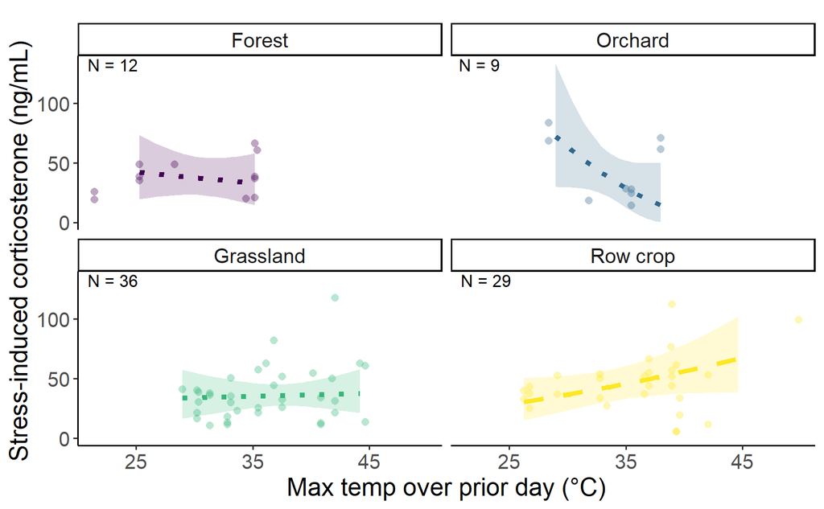

```r
samp_s2_priordayt_tres <- s2_lintemp@frame %>% group_by(habitat) %>% summarize(count = n())
# samp_s2_priordayt_tres %>% gt() %>% gtsave("figures/ss_tres_s2_priordayt_.html")


dat_text_s2_priordayt_tres <- data.frame(
  label = paste("N =",samp_s2_priordayt_tres$count),
  group   = factor(c("Forest","Orchard","Grassland","Row crop"))
)





data_s2_priordayt_tres = dplyr::filter(g,Species == "TRES",!is.na(maxt_prior),!is.na(mint_prior)) %>%
  mutate(across(c(gweight,maxt_prior,mint_prior,juliandate,brood_size,age),
                ~ scale(.x)[,1],
                .names = "{.col}_scaled"),
         maxt_prior_scaled_sq = maxt_prior_scaled * maxt_prior_scaled)


mean_temp_s2_priordayt_tres <- mean(data_s2_priordayt_tres %>% pull(maxt_prior))
sd_temp_s2_priordayt_tres <- sd(data_s2_priordayt_tres %>% pull(maxt_prior))


temp_trans_s2_priordayt_tres <- trans_new("temp_trans_s2_priordayt_tres",
                                          transform = function(x){(x * sd_temp_s2_priordayt_tres) + mean_temp_s2_priordayt_tres},
                                          inverse = function(x){x})

(fig_priordayt_tres_s2 <- ggpredict(prior_model,terms = c("maxt_prior_scaled [all]","habitat"),bias_correction = TRUE) %>%
    plot(line_size = 1.5,alpha = .2,show_data = TRUE,limit_range = TRUE) +
    aes(linetype = .data[["group"]]) +
    theme_classic() +
    facet_wrap(~ group, ncol = 2) +
    xlab("Max temp over prior day (\u00b0C)") +
    ylab("Stress-induced corticosterone (ng/mL)") +
    scale_fill_viridis(discrete = TRUE) +
    scale_color_viridis(discrete = TRUE) +
    theme(text = element_text(size = 16)) +
    labs(title = element_blank()) +
    scale_x_continuous(trans = temp_trans_s2_priordayt_tres,
                       breaks = c((25-mean_temp_s2_priordayt_tres)/sd_temp_s2_priordayt_tres,
                                  (35-mean_temp_s2_priordayt_tres)/sd_temp_s2_priordayt_tres,
                                  (45-mean_temp_s2_priordayt_tres)/sd_temp_s2_priordayt_tres,
                                  (55-mean_temp_s2_priordayt_tres)/sd_temp_s2_priordayt_tres,
                                  (65-mean_temp_s2_priordayt_tres)/sd_temp_s2_priordayt_tres),
                       # breaks = c(20,30,40,50),
                       # labels = c("20","30","40","50"),
                       # limits = c((15-mean(g$meanmaxtempI,na.rm = TRUE))/sd(g$meanmaxtempI,na.rm = TRUE),
                       #            (55-mean(g$meanmaxtempI,na.rm = TRUE))/sd(g$meanmaxtempI,na.rm = TRUE))
                       # limits = c(18,5)
    ) +
    scale_linetype_manual(values = c("dotted","dotted","dotted","dashed")) +
    #ylim(-5,5) +
    geom_text(data = dat_text_s2_priordayt_tres, mapping = aes(x = -Inf, y = Inf,label = label),hjust = -.2, vjust = 1.2,inherit.aes = FALSE) +
    theme(legend.position = "none")
)
```

```
G3;Model has sqrt-transformed response. Back-transforming predictions to original response scale. Standard
  errors are still on the transformed scale.
gG3;Data points may overlap. Use the `jitter` argument to add some amount of random variation to the
  location of data points and avoid overplotting.
gScale for colour is already present.
```

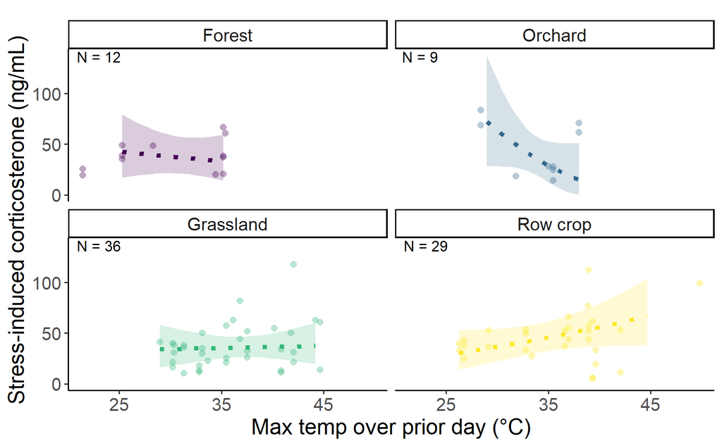

```r
(fig_priordayt_tres_s2 <- ggpredict(s2_lintemp,terms = c("maxt_prior_scaled [all]","habitat"),bias_correction = TRUE) %>%
    plot(line_size = 1.5,alpha = .2,show_data = TRUE,limit_range = TRUE) +
    aes(linetype = .data[["group"]]) +
    theme_classic() +
    facet_wrap(~ group, ncol = 2) +
    xlab("Max temp over prior day (\u00b0C)") +
    ylab("Stress-induced corticosterone (ng/mL)") +
    scale_fill_viridis(discrete = TRUE) +
    scale_color_viridis(discrete = TRUE) +
    theme(text = element_text(size = 16)) +
    labs(title = element_blank()) +
    scale_x_continuous(trans = temp_trans_s2_priordayt_tres,
                       breaks = c((25-mean_temp_s2_priordayt_tres)/sd_temp_s2_priordayt_tres,
                                  (35-mean_temp_s2_priordayt_tres)/sd_temp_s2_priordayt_tres,
                                  (45-mean_temp_s2_priordayt_tres)/sd_temp_s2_priordayt_tres,
                                  (55-mean_temp_s2_priordayt_tres)/sd_temp_s2_priordayt_tres,
                                  (65-mean_temp_s2_priordayt_tres)/sd_temp_s2_priordayt_tres),
                       # breaks = c(20,30,40,50),
                       # labels = c("20","30","40","50"),
                       # limits = c((15-mean(g$meanmaxtempI,na.rm = TRUE))/sd(g$meanmaxtempI,na.rm = TRUE),
                       #            (55-mean(g$meanmaxtempI,na.rm = TRUE))/sd(g$meanmaxtempI,na.rm = TRUE))
                       # limits = c(18,5)
    ) +
    scale_linetype_manual(values = c("dotted","dotted","dotted","dotted")) +
    #ylim(-5,5) +
    geom_text(data = dat_text_s2_priordayt_tres, mapping = aes(x = -Inf, y = Inf,label = label),hjust = -.2, vjust = 1.2,inherit.aes = FALSE) +
    theme(legend.position = "none")
)
```

```
G3;Model has sqrt-transformed response. Back-transforming predictions to original response scale. Standard
  errors are still on the transformed scale.
gG3;Data points may overlap. Use the `jitter` argument to add some amount of random variation to the
  location of data points and avoid overplotting.
g
```

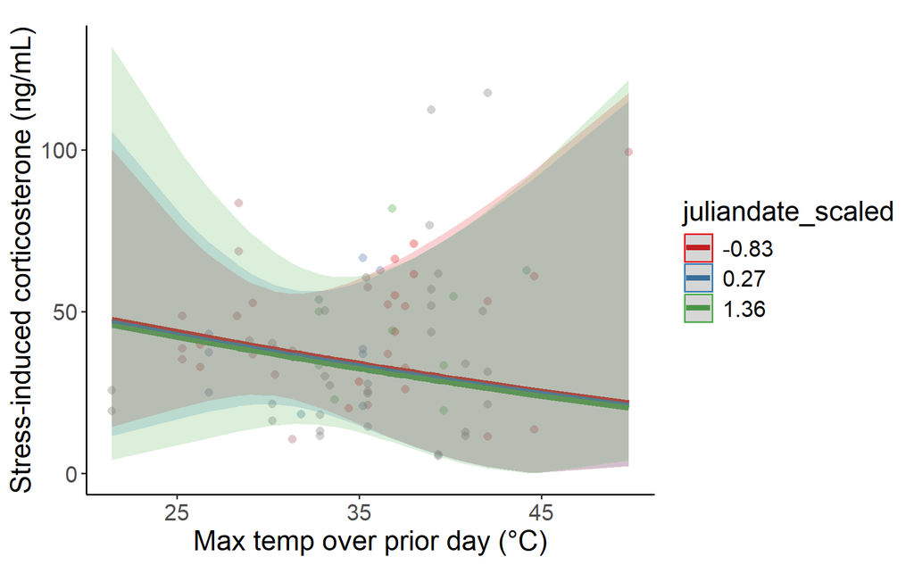

```r
(fig_priordayt_tres_s2 <- ggpredict(s2_lintemp,terms = c("maxt_prior_scaled [all]","juliandate_scaled"),bias_correction = TRUE) %>%
    plot(line_size = 1.5,alpha = .2,show_data = TRUE,limit_range = TRUE) +
    # aes(linetype = .data[["group"]]) +
    theme_classic() +
    # facet_wrap(~ group, ncol = 2) +
    xlab("Max temp over prior day (\u00b0C)") +
    ylab("Stress-induced corticosterone (ng/mL)") +
    # scale_fill_viridis(discrete = TRUE) +
    # scale_color_viridis(discrete = TRUE) +
    theme(text = element_text(size = 16)) +
    labs(title = element_blank()) +
    scale_x_continuous(trans = temp_trans_s2_priordayt_tres,
                       breaks = c((25-mean_temp_s2_priordayt_tres)/sd_temp_s2_priordayt_tres,
                                  (35-mean_temp_s2_priordayt_tres)/sd_temp_s2_priordayt_tres,
                                  (45-mean_temp_s2_priordayt_tres)/sd_temp_s2_priordayt_tres,
                                  (55-mean_temp_s2_priordayt_tres)/sd_temp_s2_priordayt_tres,
                                  (65-mean_temp_s2_priordayt_tres)/sd_temp_s2_priordayt_tres),
                       # breaks = c(20,30,40,50),
                       # labels = c("20","30","40","50"),
                       # limits = c((15-mean(g$meanmaxtempI,na.rm = TRUE))/sd(g$meanmaxtempI,na.rm = TRUE),
                       #            (55-mean(g$meanmaxtempI,na.rm = TRUE))/sd(g$meanmaxtempI,na.rm = TRUE))
                       # limits = c(18,5)
    ) # +
    # scale_linetype_manual(values = c("dotted","dotted","dotted","dashed")) +
    # #ylim(-5,5) +
    # geom_text(data = dat_text_s2_priordayt_tres, mapping = aes(x = -Inf, y = Inf,label = label),hjust = -.2, vjust = 1.2,inherit.aes = FALSE) +
    # theme(legend.position = "none")
)
```

Interaction is not significant

### Provis

#### WEBL

```r
prior_model <- glmmTMB(valid_detections ~ mean_temp_scaled * habitat + poly(mean_temp_scaled,2) + julian_date_scaled + poly(tod_h_scaled,2) + mean_nestling_age_scaled + (1|attempt_id) + year_fct,
                    ziformula = ~ 1,
                    family = nbinom2(),
                    data = dplyr::filter(p,!is.na(mean_temp),
                                         !is.na(julian_date),
                                         !is.na(mean_nestling_age),
                                         !is.na(tod_h),
                                         !is.na(site),
                                         !is.na(attempt_id),
                                         !is.na(year),
                                         species == "WEBL"# ,
                                         # tod >= hms::as.hms('11:00:00', tz = "America/Los_Angeles"),
                                         # tod_end <= hms::as.hms('17:00:00',tz = "America/Los_Angeles"),
                                         # tod_end >= hms::as.hms('11:00:00', tz = "America/Los_Angeles")
                    ) %>%
                      mutate(across(c(tod_h,mean_temp,julian_date,mean_nestling_age),
                                    ~ scale(.x)[,1],
                                    .names = "{.col}_scaled")))
```

```
G3;dropping columns from rank-deficient conditional model: poly(mean_temp_scaled, 2)1
g
```

```r
m <- glmmTMB(valid_detections ~ poly(mean_temp_scaled,2) * habitat + mean_temp_scaled * julian_date_scaled + poly(tod_h_scaled,2) + mean_nestling_age_scaled + (1|attempt_id) + year_fct,
             ziformula = ~ 1,
             family = nbinom2(),
             data = dplyr::filter(p,!is.na(mean_temp),
                                  !is.na(julian_date),
                                  !is.na(mean_nestling_age),
                                  !is.na(tod_h),
                                  !is.na(site),
                                  !is.na(attempt_id),
                                  !is.na(year),
                                  species == "WEBL"# ,
                                  # tod >= hms::as.hms('11:00:00', tz = "America/Los_Angeles"),
                                  # tod_end <= hms::as.hms('17:00:00',tz = "America/Los_Angeles"),
                                  # tod_end >= hms::as.hms('11:00:00', tz = "America/Los_Angeles")
             ) %>%
               mutate(across(c(tod_h,mean_temp,julian_date,mean_nestling_age),
                             ~ scale(.x)[,1],
                             .names = "{.col}_scaled")))
```

```
G3;dropping columns from rank-deficient conditional model: mean_temp_scaled
g
```

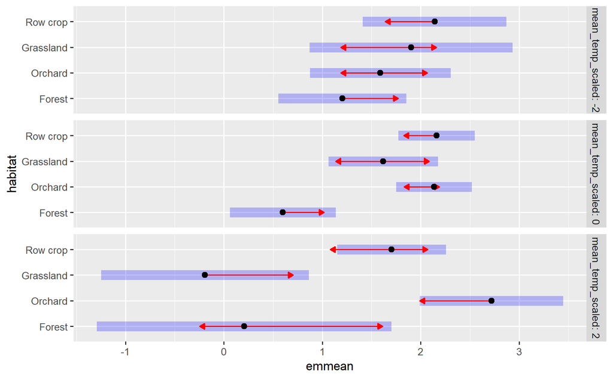

```r
emmeans(m,specs = pairwise ~ habitat,by = c("mean_temp_scaled"), at = list(mean_temp_scaled = c(-2,0,2))) %>% plot(comparisons = TRUE)
```

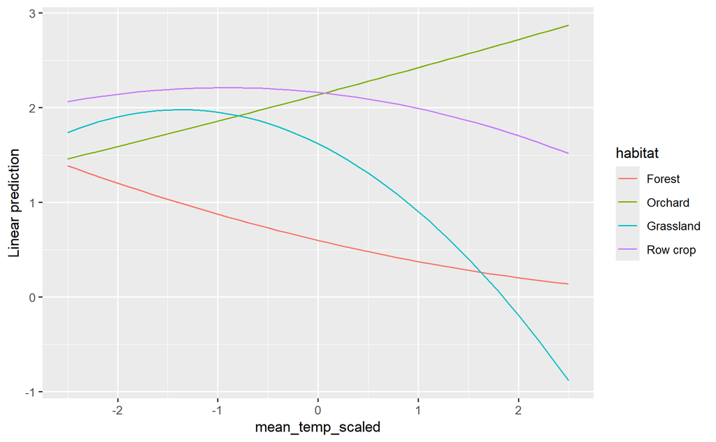

```r
emmip(m,formula = habitat ~ mean_temp_scaled, at = list(mean_temp_scaled = seq(from = -2.5, to = 2.5, by = .1)))
```

```r
m_linint <- glmmTMB(valid_detections ~ mean_temp_scaled * habitat + poly(mean_temp_scaled,2) + mean_temp_scaled * julian_date_scaled + poly(tod_h_scaled,2) + mean_nestling_age_scaled + (1|attempt_id) + year_fct,
                    ziformula = ~ 1,
                    family = nbinom2(),
                    data = dplyr::filter(p,!is.na(mean_temp),
                                         !is.na(julian_date),
                                         !is.na(mean_nestling_age),
                                         !is.na(tod_h),
                                         !is.na(site),
                                         !is.na(attempt_id),
                                         !is.na(year),
                                         species == "WEBL"# ,
                                         # tod >= hms::as.hms('11:00:00', tz = "America/Los_Angeles"),
                                         # tod_end <= hms::as.hms('17:00:00',tz = "America/Los_Angeles"),
                                         # tod_end >= hms::as.hms('11:00:00', tz = "America/Los_Angeles")
                    ) %>%
                      mutate(across(c(tod_h,mean_temp,julian_date,mean_nestling_age),
                                    ~ scale(.x)[,1],
                                    .names = "{.col}_scaled")))
```

```
G3;dropping columns from rank-deficient conditional model: poly(mean_temp_scaled, 2)1
g
```

```r
m_noint <- glmmTMB(valid_detections ~ poly(mean_temp_scaled,2) + habitat + mean_temp_scaled * julian_date_scaled + poly(tod_h_scaled,2) + mean_nestling_age_scaled + (1|attempt_id) + year_fct,
                   ziformula = ~ 1,
                   family = nbinom2(),
                   data = dplyr::filter(p,!is.na(mean_temp),
                                        !is.na(julian_date),
                                        !is.na(mean_nestling_age),
                                        !is.na(tod_h),
                                        !is.na(site),
                                        !is.na(attempt_id),
                                        !is.na(year),
                                        species == "WEBL"# ,
                                        # tod >= hms::as.hms('11:00:00', tz = "America/Los_Angeles"),
                                        # tod_end <= hms::as.hms('17:00:00',tz = "America/Los_Angeles"),
                                        # tod_end >= hms::as.hms('11:00:00', tz = "America/Los_Angeles")
                   ) %>%
                     mutate(across(c(tod_h,mean_temp,julian_date,mean_nestling_age),
                                   ~ scale(.x)[,1],
                                   .names = "{.col}_scaled")))
```

```
G3;dropping columns from rank-deficient conditional model: mean_temp_scaled
g
```

```r
c <- anova(m,m_linint,m_noint) %>% tibble() %>% mutate(Model = c("No temp * LC interaction","linear temp * LC interaction", "quadratic temp * LC  interaction"),.before = Df)

(int_tab_provis_webl <- c %>%
    as.tibble() %>%
    mutate(across(where(is.numeric),~round(.x,digits = 4)),
           P = `Pr(>Chisq)`) %>%
    dplyr::select(Model,AIC,Chisq,P) %>%
    mutate(across(c(AIC,Chisq), ~ round(.x, digits = 2)),
           P = if_else(P < 0.001,"<0.001",as.character(P))) %>% gt())
```

| Model | AIC | Chisq | P |
| --- | --- | --- | --- |
| No temp * LC interaction | 1880.31 | NA | NA |
| linear temp * LC interaction | 1858.93 | 27.38 | <0.001 |
| quadratic temp * LC interaction | 1862.25 | 2.68 | 0.4431 |

```r
# gtsave(int_tab_provis_webl,"figures/int_tab_provis_webl.html")

summary(m_linint)
```

```
 Family: nbinom2  ( log )
Formula:          valid_detections ~ mean_temp_scaled * habitat + poly(mean_temp_scaled,
    2) + mean_temp_scaled * julian_date_scaled + poly(tod_h_scaled,
    2) + mean_nestling_age_scaled + (1 | attempt_id) + year_fct
Zero inflation:                    ~1
Data: dplyr::filter(p, !is.na(mean_temp), !is.na(julian_date), !is.na(mean_nestling_age),
    !is.na(tod_h), !is.na(site), !is.na(attempt_id), !is.na(year),
    species == "WEBL") %>% mutate(across(c(tod_h, mean_temp,
    julian_date, mean_nestling_age), ~scale(.x)[, 1], .names = "{.col}_scaled"))

     AIC      BIC   logLik deviance df.resid
  1858.9   1930.4   -910.5   1820.9      298

Random effects:

Conditional model:
 Groups     Name        Variance Std.Dev.
 attempt_id (Intercept) 0.1371   0.3703
Number of obs: 317, groups:  attempt_id, 29

Dispersion parameter for nbinom2 family ():  4.3

Conditional model:
                                    Estimate Std. Error z value Pr(>|z|)
(Intercept)                          0.64322    0.41710   1.542 0.123049
mean_temp_scaled                    -0.34385    0.13361  -2.574 0.010066 *
habitatOrchard                       1.58431    0.28147   5.629 1.82e-08 ***
habitatGrassland                     0.87435    0.33760   2.590 0.009600 **
habitatRow crop                      1.54070    0.29246   5.268 1.38e-07 ***
poly(mean_temp_scaled, 2)1                NA         NA      NA       NA
poly(mean_temp_scaled, 2)2          -0.94560    0.91585  -1.032 0.301845
julian_date_scaled                  -0.01230    0.09889  -0.124 0.901032
poly(tod_h_scaled, 2)1              -0.80704    0.72094  -1.119 0.262955
poly(tod_h_scaled, 2)2               1.60436    1.19560   1.342 0.179633
mean_nestling_age_scaled             0.16730    0.05725   2.923 0.003472 **
year_fct2022                         0.12313    0.33844   0.364 0.716002
year_fct2023                        -0.16125    0.33236  -0.485 0.627545
mean_temp_scaled:habitatOrchard      0.61479    0.16400   3.749 0.000178 ***
mean_temp_scaled:habitatGrassland   -0.16461    0.19031  -0.865 0.387067
mean_temp_scaled:habitatRow crop     0.24530    0.16900   1.451 0.146647
mean_temp_scaled:julian_date_scaled  0.13959    0.05707   2.446 0.014453 *
---
Signif. codes:  0 '***' 0.001 '**' 0.01 '*' 0.05 '.' 0.1 ' ' 1

Zero-inflation model:
            Estimate Std. Error z value Pr(>|z|)
(Intercept)  -2.8859     0.4866  -5.931 3.01e-09 ***
---
Signif. codes:  0 '***' 0.001 '**' 0.01 '*' 0.05 '.' 0.1 ' ' 1
```

```r
check_collinearity(m_noint)
```

```
G3;Model matrix is rank deficient. VIFs may not be sensible.
g
```

```
# Check for Multicollinearity

* conditional component:

Low Correlation

                                Term  VIF   VIF 95% CI Increased SE Tolerance Tolerance 95% CI
           poly(mean_temp_scaled, 2) 3.16 [2.67, 3.79]         1.78      0.32     [0.26, 0.37]
                             habitat 1.61 [1.42, 1.89]         1.27      0.62     [0.53, 0.70]
                  julian_date_scaled 1.76 [1.54, 2.07]         1.33      0.57     [0.48, 0.65]
               poly(tod_h_scaled, 2) 2.42 [2.07, 2.88]         1.55      0.41     [0.35, 0.48]
            mean_nestling_age_scaled 1.52 [1.35, 1.79]         1.23      0.66     [0.56, 0.74]
                            year_fct 1.39 [1.24, 1.63]         1.18      0.72     [0.61, 0.80]
 mean_temp_scaled:julian_date_scaled 1.55 [1.37, 1.81]         1.24      0.65     [0.55, 0.73]
```

```r
provis_webl <- m_linint

summary(m_linint)
```

```
 Family: nbinom2  ( log )
Formula:          valid_detections ~ mean_temp_scaled * habitat + poly(mean_temp_scaled,
    2) + mean_temp_scaled * julian_date_scaled + poly(tod_h_scaled,
    2) + mean_nestling_age_scaled + (1 | attempt_id) + year_fct
Zero inflation:                    ~1
Data: dplyr::filter(p, !is.na(mean_temp), !is.na(julian_date), !is.na(mean_nestling_age),
    !is.na(tod_h), !is.na(site), !is.na(attempt_id), !is.na(year),
    species == "WEBL") %>% mutate(across(c(tod_h, mean_temp,
    julian_date, mean_nestling_age), ~scale(.x)[, 1], .names = "{.col}_scaled"))

     AIC      BIC   logLik deviance df.resid
  1858.9   1930.4   -910.5   1820.9      298

Random effects:

Conditional model:
 Groups     Name        Variance Std.Dev.
 attempt_id (Intercept) 0.1371   0.3703
Number of obs: 317, groups:  attempt_id, 29

Dispersion parameter for nbinom2 family ():  4.3

Conditional model:
                                    Estimate Std. Error z value Pr(>|z|)
(Intercept)                          0.64322    0.41710   1.542 0.123049
mean_temp_scaled                    -0.34385    0.13361  -2.574 0.010066 *
habitatOrchard                       1.58431    0.28147   5.629 1.82e-08 ***
habitatGrassland                     0.87435    0.33760   2.590 0.009600 **
habitatRow crop                      1.54070    0.29246   5.268 1.38e-07 ***
poly(mean_temp_scaled, 2)1                NA         NA      NA       NA
poly(mean_temp_scaled, 2)2          -0.94560    0.91585  -1.032 0.301845
julian_date_scaled                  -0.01230    0.09889  -0.124 0.901032
poly(tod_h_scaled, 2)1              -0.80704    0.72094  -1.119 0.262955
poly(tod_h_scaled, 2)2               1.60436    1.19560   1.342 0.179633
mean_nestling_age_scaled             0.16730    0.05725   2.923 0.003472 **
year_fct2022                         0.12313    0.33844   0.364 0.716002
year_fct2023                        -0.16125    0.33236  -0.485 0.627545
mean_temp_scaled:habitatOrchard      0.61479    0.16400   3.749 0.000178 ***
mean_temp_scaled:habitatGrassland   -0.16461    0.19031  -0.865 0.387067
mean_temp_scaled:habitatRow crop     0.24530    0.16900   1.451 0.146647
mean_temp_scaled:julian_date_scaled  0.13959    0.05707   2.446 0.014453 *
---
Signif. codes:  0 '***' 0.001 '**' 0.01 '*' 0.05 '.' 0.1 ' ' 1

Zero-inflation model:
            Estimate Std. Error z value Pr(>|z|)
(Intercept)  -2.8859     0.4866  -5.931 3.01e-09 ***
---
Signif. codes:  0 '***' 0.001 '**' 0.01 '*' 0.05 '.' 0.1 ' ' 1
```

```r
anova(m_linint,prior_model)
```

```
Data: dplyr::filter(p, !is.na(mean_temp), !is.na(julian_date), !is.na(mean_nestling_age),  ...
Models:
prior_model: valid_detections ~ mean_temp_scaled * habitat + poly(mean_temp_scaled, , zi=~1, disp=~1
prior_model:     2) + julian_date_scaled + poly(tod_h_scaled, 2) + mean_nestling_age_scaled + , zi=~1, disp=~1
prior_model:     (1 | attempt_id) + year_fct, zi=~1, disp=~1
m_linint: valid_detections ~ mean_temp_scaled * habitat + poly(mean_temp_scaled, , zi=~1, disp=~1
m_linint:     2) + mean_temp_scaled * julian_date_scaled + poly(tod_h_scaled, , zi=~1, disp=~1
m_linint:     2) + mean_nestling_age_scaled + (1 | attempt_id) + year_fct, zi=~1, disp=~1
            Df    AIC    BIC  logLik deviance  Chisq Chi Df Pr(>Chisq)
prior_model 18 1862.8 1930.5 -913.42   1826.8
m_linint    19 1858.9 1930.3 -910.47   1820.9 5.8986      1    0.01515 *
---
Signif. codes:  0 '***' 0.001 '**' 0.01 '*' 0.05 '.' 0.1 ' ' 1
```

Interaction is significant, improves fit, does not change parsimony

```r
(weblprovistrend_prior <- emtrends(prior_model,specs = ~ habitat, var = c("mean_temp_scaled"),max.degree = 1) %>% test() %>%
    mutate(across(where(is.numeric), ~ round(.x, digits = 3)),
           df = round(df),
           p.value = if_else(p.value == 0.000,"<0.001",as.character(p.value))) %>%
    rename(Habitat = "habitat", `Max temp trend` = "mean_temp_scaled.trend",Df = "df", `Z-ratio` = "z.ratio", P = "p.value") %>%
    #group_by(degree) %>%
    gt())
```

| Habitat | Max temp trend | SE | Df | Z-ratio | P |
| --- | --- | --- | --- | --- | --- |
| Forest | -0.403 | 0.139 | Inf | -2.901 | 0.004 |
| Orchard | 0.222 | 0.119 | Inf | 1.868 | 0.062 |
| Grassland | -0.528 | 0.145 | Inf | -3.634 | <0.001 |
| Row crop | -0.064 | 0.100 | Inf | -0.640 | 0.522 |

```r
(weblprovistrend <- emtrends(m_linint,specs = ~ habitat, var = c("mean_temp_scaled"),max.degree = 1) %>% test() %>%
    mutate(across(where(is.numeric), ~ round(.x, digits = 3)),
           df = round(df),
           p.value = if_else(p.value == 0.000,"<0.001",as.character(p.value))) %>%
    rename(Habitat = "habitat", `Max temp trend` = "mean_temp_scaled.trend",Df = "df", `Z-ratio` = "z.ratio", P = "p.value") %>%
    #group_by(degree) %>%
    gt())
```

| Habitat | Max temp trend | SE | Df | Z-ratio | P |
| --- | --- | --- | --- | --- | --- |
| Forest | -0.356 | 0.137 | Inf | -2.601 | 0.009 |
| Orchard | 0.258 | 0.117 | Inf | 2.215 | 0.027 |
| Grassland | -0.521 | 0.145 | Inf | -3.591 | <0.001 |
| Row crop | -0.111 | 0.101 | Inf | -1.105 | 0.269 |

Same trends, but makes orchard trend slightly more significant

```
G3;Data points may overlap. Use the `jitter` argument to add some amount of random variation to the
  location of data points and avoid overplotting.
gScale for colour is already present.
```

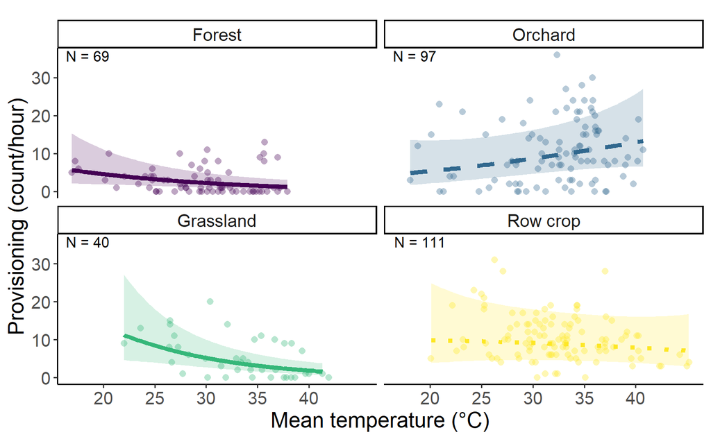

```r
samp <- m_linint$frame %>% group_by(habitat) %>% summarize(count = n())
# samp %>% gt() %>% gtsave("figures/ss_webl_provis.html")


dat_text_webl <- data.frame(
  label = paste("N =",samp$count),
  group   = factor(c("Forest","Orchard","Grassland","Row crop"))
)

data_webl = dplyr::filter(p,!is.na(mean_temp),
                          !is.na(julian_date),
                          !is.na(mean_nestling_age),
                          !is.na(tod_h),
                          !is.na(site),
                          !is.na(attempt_id),
                          !is.na(year),
                          species == "WEBL"# ,
                          # tod >= hms::as.hms('11:00:00', tz = "America/Los_Angeles"),
                          # tod_end <= hms::as.hms('17:00:00',tz = "America/Los_Angeles"),
                          # tod_end >= hms::as.hms('11:00:00', tz = "America/Los_Angeles")
) %>%
  mutate(across(c(tod_h,mean_temp,julian_date,mean_nestling_age),
                ~ scale(.x)[,1],
                .names = "{.col}_scaled"))


mean_temp_webl <- mean(data_webl %>% pull(mean_temp))
sd_temp_webl <- sd(data_webl %>% pull(mean_temp))


temp_trans_webl <- trans_new("temp_trans_webl",
                             transform = function(x){(x * sd_temp_webl) + mean_temp_webl},
                             inverse = function(x){x})

(fig5_webl <- predict_response(prior_model,terms = c("mean_temp_scaled [all]","habitat"),bias_correction = TRUE) %>%
    plot(line_size = 1.5,alpha = .2,show_data = TRUE,limit_range = TRUE) +
    aes(linetype = .data[["group"]]) +
    theme_classic() +
    facet_wrap(~ group, ncol = 2) +
    xlab("Mean temperature (\u00b0C)") +
    ylab("Provisioning (count/hour)") +
    scale_fill_viridis(discrete = TRUE) +
    scale_color_viridis(discrete = TRUE) +
    theme(text = element_text(size = 16)) +
    labs(title =  element_blank()) +
    scale_x_continuous(trans = temp_trans_webl,
                       breaks = c((20-mean_temp_webl)/sd_temp_webl,
                                  (25-mean_temp_webl)/sd_temp_webl,
                                  (30-mean_temp_webl)/sd_temp_webl,
                                  (35-mean_temp_webl)/sd_temp_webl,
                                  (40-mean_temp_webl)/sd_temp_webl),
                       # breaks = c(20,30,40,50),
                       # labels = c("20","30","40","50"),
                       # limits = c((15-mean(g$meanmaxtempI,na.rm = TRUE))/sd(g$meanmaxtempI,na.rm = TRUE),
                       #            (55-mean(g$meanmaxtempI,na.rm = TRUE))/sd(g$meanmaxtempI,na.rm = TRUE))
                       # limits = c(18,5)
    ) +
    scale_linetype_manual(values = c("Forest" = "solid","Orchard" = "dashed","Grassland" = "solid","Row crop" = "dotted")) +
    #ylim(-5,5) +
    geom_text(data = dat_text_webl, mapping = aes(x = -Inf, y = Inf,label = label),hjust = -.2, vjust = 1.2,inherit.aes = FALSE) +
    theme(legend.position = "none")
)
```

```
G3;Data points may overlap. Use the `jitter` argument to add some amount of random variation to the
  location of data points and avoid overplotting.
gScale for colour is already present.
```

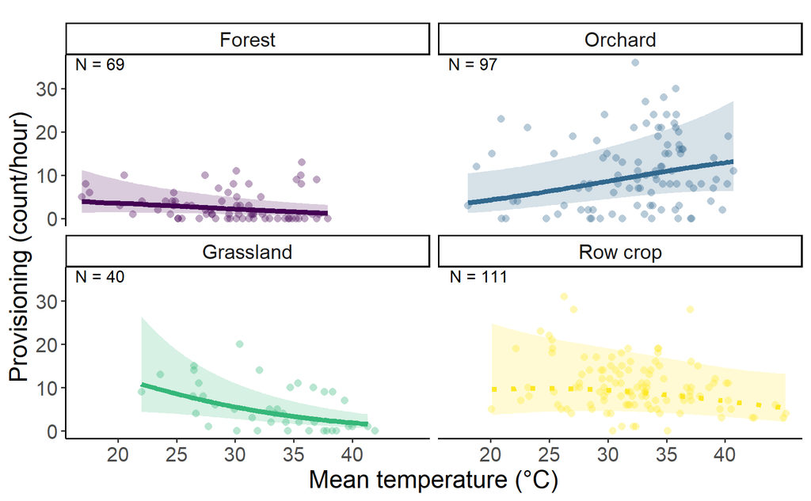

```r
(fig5_webl <- predict_response(m_linint,terms = c("mean_temp_scaled [all]","habitat"),bias_correction = TRUE) %>%
    plot(line_size = 1.5,alpha = .2,show_data = TRUE,limit_range = TRUE) +
    aes(linetype = .data[["group"]]) +
    theme_classic() +
    facet_wrap(~ group, ncol = 2) +
    xlab("Mean temperature (\u00b0C)") +
    ylab("Provisioning (count/hour)") +
    scale_fill_viridis(discrete = TRUE) +
    scale_color_viridis(discrete = TRUE) +
    theme(text = element_text(size = 16)) +
    labs(title =  element_blank()) +
    scale_x_continuous(trans = temp_trans_webl,
                       breaks = c((20-mean_temp_webl)/sd_temp_webl,
                                  (25-mean_temp_webl)/sd_temp_webl,
                                  (30-mean_temp_webl)/sd_temp_webl,
                                  (35-mean_temp_webl)/sd_temp_webl,
                                  (40-mean_temp_webl)/sd_temp_webl),
                       # breaks = c(20,30,40,50),
                       # labels = c("20","30","40","50"),
                       # limits = c((15-mean(g$meanmaxtempI,na.rm = TRUE))/sd(g$meanmaxtempI,na.rm = TRUE),
                       #            (55-mean(g$meanmaxtempI,na.rm = TRUE))/sd(g$meanmaxtempI,na.rm = TRUE))
                       # limits = c(18,5)
    ) +
    scale_linetype_manual(values = c("Forest" = "solid","Orchard" = "solid","Grassland" = "solid","Row crop" = "dotted")) +
    #ylim(-5,5) +
    geom_text(data = dat_text_webl, mapping = aes(x = -Inf, y = Inf,label = label),hjust = -.2, vjust = 1.2,inherit.aes = FALSE) +
    theme(legend.position = "none")
)
```

```
G3;Data points may overlap. Use the `jitter` argument to add some amount of random variation to the
  location of data points and avoid overplotting.
g
```

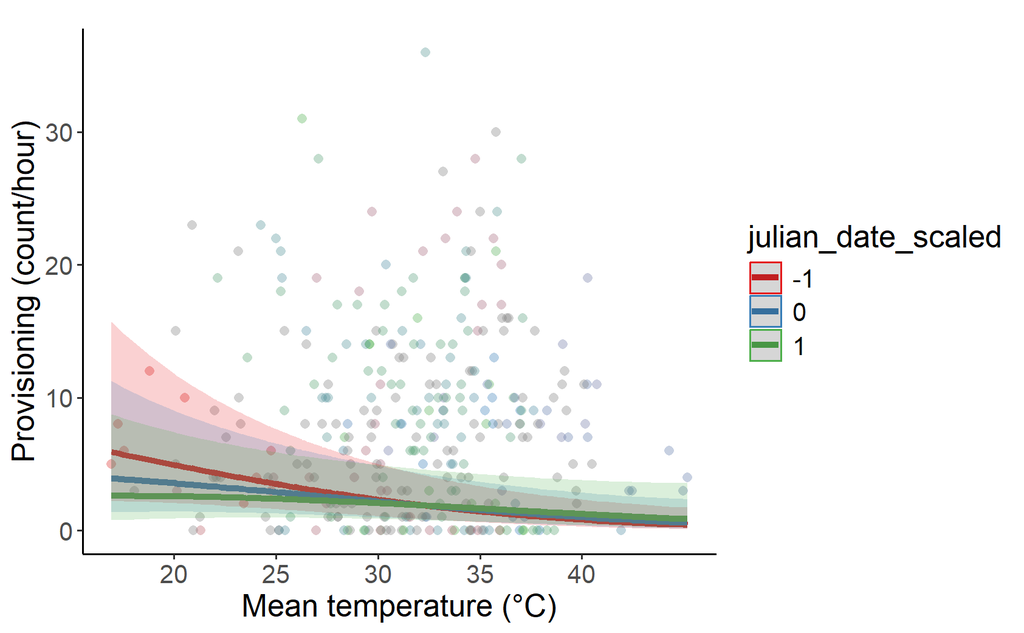

```r
(fig5_webl <- predict_response(m_linint,terms = c("mean_temp_scaled [all]","julian_date_scaled"),bias_correction = TRUE) %>%
    plot(line_size = 1.5,alpha = .2,show_data = TRUE,limit_range = TRUE) +
    # aes(linetype = .data[["group"]]) +
    theme_classic() +
    # facet_wrap(~ group, ncol = 2) +
    xlab("Mean temperature (\u00b0C)") +
    ylab("Provisioning (count/hour)") +
    # scale_fill_viridis(discrete = TRUE) +
    # scale_color_viridis(discrete = TRUE) +
    theme(text = element_text(size = 16)) +
    labs(title =  element_blank()) +
    scale_x_continuous(trans = temp_trans_webl,
                       breaks = c((20-mean_temp_webl)/sd_temp_webl,
                                  (25-mean_temp_webl)/sd_temp_webl,
                                  (30-mean_temp_webl)/sd_temp_webl,
                                  (35-mean_temp_webl)/sd_temp_webl,
                                  (40-mean_temp_webl)/sd_temp_webl),
                       # breaks = c(20,30,40,50),
                       # labels = c("20","30","40","50"),
                       # limits = c((15-mean(g$meanmaxtempI,na.rm = TRUE))/sd(g$meanmaxtempI,na.rm = TRUE),
                       #            (55-mean(g$meanmaxtempI,na.rm = TRUE))/sd(g$meanmaxtempI,na.rm = TRUE))
                       # limits = c(18,5)
    ) # +
    # scale_linetype_manual(values = c("Forest" = "solid","Orchard" = "dashed","Grassland" = "solid","Row crop" = "dotted")) +
    # #ylim(-5,5) +
    # geom_text(data = dat_text_webl, mapping = aes(x = -Inf, y = Inf,label = label),hjust = -.2, vjust = 1.2,inherit.aes = FALSE) +
    # theme(legend.position = "none")
)
```

Higher mean temp is worse for provisioning in the early season relative to late season.

#### TRES

```r
prior_model <- glmmTMB(valid_detections ~ poly(mean_temp_scaled,2) * habitat + julian_date_scaled + poly(tod_h_scaled,2) + mean_nestling_age_scaled + (1|attempt_id) + year_fct,
             ziformula = ~ 1,
             family = nbinom2(),
             data = dplyr::filter(p,!is.na(mean_temp),
                                  !is.na(julian_date),
                                  !is.na(mean_nestling_age),
                                  !is.na(tod_h),
                                  !is.na(site),
                                  !is.na(attempt_id),
                                  !is.na(year),
                                  valid_detections < 40,
                                  species == "TRES"# ,
                                  # tod >= hms::as.hms('11:00:00', tz = "America/Los_Angeles"),
                                  # tod_end <= hms::as.hms('17:00:00',tz = "America/Los_Angeles"),
                                  # tod_end >= hms::as.hms('11:00:00', tz = "America/Los_Angeles")
             ) %>%
               mutate(across(c(tod_h,mean_temp,julian_date,mean_nestling_age),
                             ~ scale(.x)[,1],
                             .names = "{.col}_scaled")))

m <- glmmTMB(valid_detections ~ poly(mean_temp_scaled,2) * habitat + mean_temp_scaled * julian_date_scaled + poly(tod_h_scaled,2) + mean_nestling_age_scaled + (1|attempt_id) + year_fct,
             ziformula = ~ 1,
             family = nbinom2(),
             data = dplyr::filter(p,!is.na(mean_temp),
                                  !is.na(julian_date),
                                  !is.na(mean_nestling_age),
                                  !is.na(tod_h),
                                  !is.na(site),
                                  !is.na(attempt_id),
                                  !is.na(year),
                                  valid_detections < 40,
                                  species == "TRES"# ,
                                  # tod >= hms::as.hms('11:00:00', tz = "America/Los_Angeles"),
                                  # tod_end <= hms::as.hms('17:00:00',tz = "America/Los_Angeles"),
                                  # tod_end >= hms::as.hms('11:00:00', tz = "America/Los_Angeles")
             ) %>%
               mutate(across(c(tod_h,mean_temp,julian_date,mean_nestling_age),
                             ~ scale(.x)[,1],
                             .names = "{.col}_scaled")))
```

```
G3;dropping columns from rank-deficient conditional model: mean_temp_scaled
g
```

```r
m_linint <- glmmTMB(valid_detections ~ mean_temp_scaled * habitat + poly(mean_temp_scaled,2) + mean_temp_scaled * julian_date_scaled + poly(tod_h_scaled,2) + mean_nestling_age_scaled + (1|attempt_id) + year_fct,
                    ziformula = ~ 1,
                    family = nbinom2(),
                    data = dplyr::filter(p,!is.na(mean_temp),
                                         !is.na(julian_date),
                                         !is.na(mean_nestling_age),
                                         !is.na(tod_h),
                                         !is.na(site),
                                         !is.na(attempt_id),
                                         !is.na(year),
                                         valid_detections < 40,
                                         species == "TRES"# ,
                                         # tod >= hms::as.hms('11:00:00', tz = "America/Los_Angeles"),
                                         # tod_end <= hms::as.hms('17:00:00',tz = "America/Los_Angeles"),
                                         # tod_end >= hms::as.hms('11:00:00', tz = "America/Los_Angeles")
                    ) %>%
                      mutate(across(c(tod_h,mean_temp,julian_date,mean_nestling_age),
                                    ~ scale(.x)[,1],
                                    .names = "{.col}_scaled")))
```

```
G3;dropping columns from rank-deficient conditional model: poly(mean_temp_scaled, 2)1
g
```

```r
m_noint <- glmmTMB(valid_detections ~ poly(mean_temp_scaled,2) + habitat + mean_temp_scaled * julian_date_scaled + poly(tod_h_scaled,2) + mean_nestling_age_scaled + (1|attempt_id) + year_fct,
                   ziformula = ~ 1,
                   family = nbinom2(),
                   data = dplyr::filter(p,!is.na(mean_temp),
                                        !is.na(julian_date),
                                        !is.na(mean_nestling_age),
                                        !is.na(tod_h),
                                        !is.na(site),
                                        !is.na(attempt_id),
                                        !is.na(year),
                                        valid_detections < 40,
                                        species == "TRES"# ,
                                        # tod >= hms::as.hms('11:00:00', tz = "America/Los_Angeles"),
                                        # tod_end <= hms::as.hms('17:00:00',tz = "America/Los_Angeles"),
                                        # tod_end >= hms::as.hms('11:00:00', tz = "America/Los_Angeles")
                   ) %>%
                     mutate(across(c(tod_h,mean_temp,julian_date,mean_nestling_age),
                                   ~ scale(.x)[,1],
                                   .names = "{.col}_scaled")))
```

```
G3;dropping columns from rank-deficient conditional model: mean_temp_scaled
g
```

```r
c <- anova(m,m_linint,m_noint) %>% tibble() %>% mutate(Model = c("No temp * LC interaction","Linear temp * LC interaction","Squared temp * LC interaction"),.before = Df)

(int_tab_provis_tres <- c %>%
    as.tibble() %>%
    mutate(across(where(is.numeric),~round(.x,digits = 4)),
           P = `Pr(>Chisq)`) %>%
    dplyr::select(Model,AIC,Chisq,P) %>%
    mutate(across(c(AIC,Chisq), ~ round(.x, digits = 2)),
           P = if_else(P < 0.001,"<0.001",as.character(P))) %>% gt())
```

| Model | AIC | Chisq | P |
| --- | --- | --- | --- |
| No temp * LC interaction | 1362.39 | NA | NA |
| Linear temp * LC interaction | 1367.50 | 0.88 | 0.8296 |
| Squared temp * LC interaction | 1361.07 | 12.43 | 0.006 |

```r
# gtsave(int_tab_provis_tres,"figures/int_tab_provis_tres.html")

summary(m)
```

```
 Family: nbinom2  ( log )
Formula:          valid_detections ~ poly(mean_temp_scaled, 2) * habitat + mean_temp_scaled *
    julian_date_scaled + poly(tod_h_scaled, 2) + mean_nestling_age_scaled +      (1 | attempt_id) + year_fct
Zero inflation:                    ~1
Data: dplyr::filter(p, !is.na(mean_temp), !is.na(julian_date), !is.na(mean_nestling_age),
    !is.na(tod_h), !is.na(site), !is.na(attempt_id), !is.na(year),
    valid_detections < 40, species == "TRES") %>% mutate(across(c(tod_h,
    mean_temp, julian_date, mean_nestling_age), ~scale(.x)[,      1], .names = "{.col}_scaled"))

     AIC      BIC   logLik deviance df.resid
  1361.1   1435.3   -658.5   1317.1      194

Random effects:

Conditional model:
 Groups     Name        Variance Std.Dev.
 attempt_id (Intercept) 0.03126  0.1768
Number of obs: 216, groups:  attempt_id, 23

Dispersion parameter for nbinom2 family (): 3.85

Conditional model:
                                             Estimate Std. Error z value Pr(>|z|)
(Intercept)                                  -0.70414    0.72850  -0.967 0.333758
poly(mean_temp_scaled, 2)1                  -43.38985   13.98517  -3.103 0.001919 **
poly(mean_temp_scaled, 2)2                  -28.05817    8.08114  -3.472 0.000516 ***
habitatOrchard                                3.35871    2.69749   1.245 0.213085
habitatGrassland                              3.45503    0.73791   4.682 2.84e-06 ***
habitatRow crop                               3.33027    0.72829   4.573 4.81e-06 ***
mean_temp_scaled                                   NA         NA      NA       NA
julian_date_scaled                           -0.08337    0.09882  -0.844 0.398826
poly(tod_h_scaled, 2)1                        1.17103    0.86096   1.360 0.173783
poly(tod_h_scaled, 2)2                        1.29523    1.26673   1.022 0.306547
mean_nestling_age_scaled                     -0.03208    0.06136  -0.523 0.601097
year_fct2022                                 -0.09700    0.22055  -0.440 0.660059
year_fct2023                                  0.18150    0.22146   0.820 0.412462
poly(mean_temp_scaled, 2)1:habitatOrchard    76.89333   45.33198   1.696 0.089843 .
poly(mean_temp_scaled, 2)2:habitatOrchard    41.76934   19.22585   2.173 0.029813 *
poly(mean_temp_scaled, 2)1:habitatGrassland  46.22564   14.26549   3.240 0.001194 **
poly(mean_temp_scaled, 2)2:habitatGrassland  27.33728    8.10412   3.373 0.000743 ***
poly(mean_temp_scaled, 2)1:habitatRow crop   45.33226   14.23214   3.185 0.001447 **
poly(mean_temp_scaled, 2)2:habitatRow crop   25.55780    8.28334   3.085 0.002032 **
mean_temp_scaled:julian_date_scaled          -0.04591    0.07306  -0.628 0.529805
---
Signif. codes:  0 '***' 0.001 '**' 0.01 '*' 0.05 '.' 0.1 ' ' 1

Zero-inflation model:
            Estimate Std. Error z value Pr(>|z|)
(Intercept)  -1.3111     0.1795  -7.303 2.82e-13 ***
---
Signif. codes:  0 '***' 0.001 '**' 0.01 '*' 0.05 '.' 0.1 ' ' 1
```

```r
check_collinearity(m)
```

```
G3;Model matrix is rank deficient. VIFs may not be sensible.
gG3;Model has interaction terms. VIFs might be inflated.
  Try to center the variables used for the interaction, or check multicollinearity among predictors of a
  model without interaction terms.
g
```

```
# Check for Multicollinearity

* conditional component:

Low Correlation

                                Term  VIF           VIF 95% CI Increased SE Tolerance Tolerance 95% CI
                  julian_date_scaled 2.36 [    1.98,     2.88]         1.54      0.42     [0.35, 0.50]
               poly(tod_h_scaled, 2) 4.34 [    3.54,     5.38]         2.08      0.23     [0.19, 0.28]
            mean_nestling_age_scaled 1.41 [    1.24,     1.69]         1.19      0.71     [0.59, 0.81]
                            year_fct 3.44 [    2.83,     4.24]         1.85      0.29     [0.24, 0.35]
 mean_temp_scaled:julian_date_scaled 1.45 [    1.28,     1.75]         1.21      0.69     [0.57, 0.78]

High Correlation

                              Term      VIF           VIF 95% CI Increased SE Tolerance Tolerance 95% CI
         poly(mean_temp_scaled, 2)  5515.82 [ 4353.44,  6988.63]        74.27  1.81e-04     [0.00, 0.00]
                           habitat  1328.06 [ 1048.28,  1682.58]        36.44  7.53e-04     [0.00, 0.00]
 poly(mean_temp_scaled, 2):habitat 4.85e+05 [3.83e+05, 6.14e+05]       696.24  2.06e-06     [0.00, 0.00]
```

```r
provis_tres <- m

summary(m)
```

```
 Family: nbinom2  ( log )
Formula:          valid_detections ~ poly(mean_temp_scaled, 2) * habitat + mean_temp_scaled *
    julian_date_scaled + poly(tod_h_scaled, 2) + mean_nestling_age_scaled +      (1 | attempt_id) + year_fct
Zero inflation:                    ~1
Data: dplyr::filter(p, !is.na(mean_temp), !is.na(julian_date), !is.na(mean_nestling_age),
    !is.na(tod_h), !is.na(site), !is.na(attempt_id), !is.na(year),
    valid_detections < 40, species == "TRES") %>% mutate(across(c(tod_h,
    mean_temp, julian_date, mean_nestling_age), ~scale(.x)[,      1], .names = "{.col}_scaled"))

     AIC      BIC   logLik deviance df.resid
  1361.1   1435.3   -658.5   1317.1      194

Random effects:

Conditional model:
 Groups     Name        Variance Std.Dev.
 attempt_id (Intercept) 0.03126  0.1768
Number of obs: 216, groups:  attempt_id, 23

Dispersion parameter for nbinom2 family (): 3.85

Conditional model:
                                             Estimate Std. Error z value Pr(>|z|)
(Intercept)                                  -0.70414    0.72850  -0.967 0.333758
poly(mean_temp_scaled, 2)1                  -43.38985   13.98517  -3.103 0.001919 **
poly(mean_temp_scaled, 2)2                  -28.05817    8.08114  -3.472 0.000516 ***
habitatOrchard                                3.35871    2.69749   1.245 0.213085
habitatGrassland                              3.45503    0.73791   4.682 2.84e-06 ***
habitatRow crop                               3.33027    0.72829   4.573 4.81e-06 ***
mean_temp_scaled                                   NA         NA      NA       NA
julian_date_scaled                           -0.08337    0.09882  -0.844 0.398826
poly(tod_h_scaled, 2)1                        1.17103    0.86096   1.360 0.173783
poly(tod_h_scaled, 2)2                        1.29523    1.26673   1.022 0.306547
mean_nestling_age_scaled                     -0.03208    0.06136  -0.523 0.601097
year_fct2022                                 -0.09700    0.22055  -0.440 0.660059
year_fct2023                                  0.18150    0.22146   0.820 0.412462
poly(mean_temp_scaled, 2)1:habitatOrchard    76.89333   45.33198   1.696 0.089843 .
poly(mean_temp_scaled, 2)2:habitatOrchard    41.76934   19.22585   2.173 0.029813 *
poly(mean_temp_scaled, 2)1:habitatGrassland  46.22564   14.26549   3.240 0.001194 **
poly(mean_temp_scaled, 2)2:habitatGrassland  27.33728    8.10412   3.373 0.000743 ***
poly(mean_temp_scaled, 2)1:habitatRow crop   45.33226   14.23214   3.185 0.001447 **
poly(mean_temp_scaled, 2)2:habitatRow crop   25.55780    8.28334   3.085 0.002032 **
mean_temp_scaled:julian_date_scaled          -0.04591    0.07306  -0.628 0.529805
---
Signif. codes:  0 '***' 0.001 '**' 0.01 '*' 0.05 '.' 0.1 ' ' 1

Zero-inflation model:
            Estimate Std. Error z value Pr(>|z|)
(Intercept)  -1.3111     0.1795  -7.303 2.82e-13 ***
---
Signif. codes:  0 '***' 0.001 '**' 0.01 '*' 0.05 '.' 0.1 ' ' 1
```

```r
anova(m,prior_model)
```

```
Data: dplyr::filter(p, !is.na(mean_temp), !is.na(julian_date), !is.na(mean_nestling_age),  ...
Models:
prior_model: valid_detections ~ poly(mean_temp_scaled, 2) * habitat + julian_date_scaled + , zi=~1, disp=~1
prior_model:     poly(tod_h_scaled, 2) + mean_nestling_age_scaled + (1 | attempt_id) + , zi=~1, disp=~1
prior_model:     year_fct, zi=~1, disp=~1
m: valid_detections ~ poly(mean_temp_scaled, 2) * habitat + mean_temp_scaled * , zi=~1, disp=~1
m:     julian_date_scaled + poly(tod_h_scaled, 2) + mean_nestling_age_scaled + , zi=~1, disp=~1
m:     (1 | attempt_id) + year_fct, zi=~1, disp=~1
            Df    AIC    BIC  logLik deviance  Chisq Chi Df Pr(>Chisq)
prior_model 21 1359.5 1430.3 -658.73   1317.5
m           22 1361.1 1435.3 -658.54   1317.1 0.3927      1     0.5309
```

Interaction is not significant, does not improve fit, does not change parsimony

```r
(tresprovistrend_prior <- emtrends(prior_model,specs = ~ degree | habitat, var = "mean_temp_scaled",max.degree = 2) %>% test() %>%
    mutate(across(where(is.numeric), ~ round(.x, digits = 3)),
           df = round(df),
           p.value = if_else(p.value == 0.000,"<0.001",as.character(p.value))) %>%
    rename(Habitat = "habitat", `Max temp trend` = "mean_temp_scaled.trend",Df = "df", `Z-ratio` = "z.ratio", P = "p.value") %>%
    group_by(Habitat) %>%
    gt())
```

| degree | Max temp trend | SE | Df | Z-ratio | P |
| --- | --- | --- | --- | --- | --- |
| Forest |  |  |  |  |  |
| linear | -2.645 | 0.870 | Inf | -3.041 | 0.002 |
| quadratic | -1.700 | 0.484 | Inf | -3.514 | <0.001 |
| Orchard |  |  |  |  |  |
| linear | 1.936 | 2.973 | Inf | 0.651 | 0.515 |
| quadratic | 0.719 | 1.138 | Inf | 0.632 | 0.528 |
| Grassland |  |  |  |  |  |
| linear | 0.233 | 0.168 | Inf | 1.389 | 0.165 |
| quadratic | -0.052 | 0.086 | Inf | -0.609 | 0.543 |
| Row crop |  |  |  |  |  |
| linear | 0.172 | 0.136 | Inf | 1.262 | 0.207 |
| quadratic | -0.172 | 0.108 | Inf | -1.593 | 0.111 |

```r
(tresprovistrend <- emtrends(m,specs = ~ degree | habitat, var = "mean_temp_scaled",max.degree = 2) %>% test() %>%
    mutate(across(where(is.numeric), ~ round(.x, digits = 3)),
           df = round(df),
           p.value = if_else(p.value == 0.000,"<0.001",as.character(p.value))) %>%
    rename(Habitat = "habitat", `Max temp trend` = "mean_temp_scaled.trend",Df = "df", `Z-ratio` = "z.ratio", P = "p.value") %>%
    group_by(Habitat) %>%
    gt())
```

| degree | Max temp trend | SE | Df | Z-ratio | P |
| --- | --- | --- | --- | --- | --- |
| Forest |  |  |  |  |  |
| linear | -2.673 | 0.879 | Inf | -3.040 | 0.002 |
| quadratic | -1.680 | 0.484 | Inf | -3.472 | 0.001 |
| Orchard |  |  |  |  |  |
| linear | 2.145 | 2.819 | Inf | 0.761 | 0.447 |
| quadratic | 0.821 | 1.088 | Inf | 0.754 | 0.451 |
| Grassland |  |  |  |  |  |
| linear | 0.201 | 0.175 | Inf | 1.150 | 0.25 |
| quadratic | -0.043 | 0.086 | Inf | -0.500 | 0.617 |
| Row crop |  |  |  |  |  |
| linear | 0.158 | 0.137 | Inf | 1.153 | 0.249 |
| quadratic | -0.150 | 0.113 | Inf | -1.322 | 0.186 |

Same trends and significance

```
G3;Data points may overlap. Use the `jitter` argument to add some amount of random variation to the
  location of data points and avoid overplotting.
gScale for colour is already present.
```

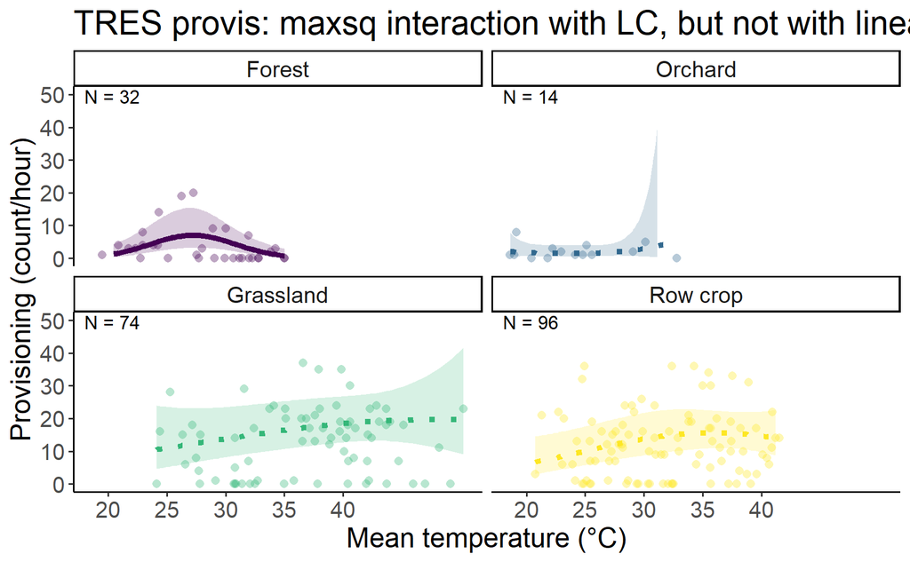

```r
samp <- m$frame %>% group_by(habitat) %>% summarize(count = n())
# samp %>% gt() %>% gtsave("figures/ss_tres_provis.html")


dat_text_tres <- data.frame(
  label = paste("N =",samp$count),
  group   = factor(c("Forest","Orchard","Grassland","Row crop"))
)





data_tres = dplyr::filter(p,!is.na(mean_temp),
                          !is.na(julian_date),
                          !is.na(mean_nestling_age),
                          !is.na(tod_h),
                          !is.na(site),
                          !is.na(attempt_id),
                          !is.na(year),
                          valid_detections < 40,
                          species == "TRES"# ,
                          # tod >= hms::as.hms('11:00:00', tz = "America/Los_Angeles"),
                          # tod_end <= hms::as.hms('17:00:00',tz = "America/Los_Angeles"),
                          # tod_end >= hms::as.hms('11:00:00', tz = "America/Los_Angeles")
) %>%
  mutate(across(c(tod_h,mean_temp,julian_date,mean_nestling_age),
                ~ scale(.x)[,1],
                .names = "{.col}_scaled"))


mean_temp_tres <- mean(data_tres %>% pull(mean_temp))
sd_temp_tres <- sd(data_tres %>% pull(mean_temp))


temp_trans_tres <- trans_new("temp_trans_tres",
                             transform = function(x){(x * sd_temp_tres) + mean_temp_tres},
                             inverse = function(x){x})

(fig5_tres <- ggpredict(prior_model,terms = c("mean_temp_scaled [all]","habitat"),bias_correction = TRUE) %>%
    plot(line_size = 1.5,alpha = .2,show_data = TRUE,limit_range = TRUE) +
    aes(linetype = .data[["group"]]) +
    theme_classic() +
    facet_wrap(~ group, ncol = 2) +
    xlab("Mean temperature (\u00b0C)") +
    ylab("Provisioning (count/hour)") +
    scale_fill_viridis(discrete = TRUE) +
    scale_color_viridis(discrete = TRUE) +
    theme(text = element_text(size = 16)) +
    labs(title = "TRES provis: maxsq interaction with LC, but not with linear max") +
    scale_x_continuous(trans = temp_trans_tres,
                       breaks = c((20-mean_temp_tres)/sd_temp_tres,
                                  (25-mean_temp_tres)/sd_temp_tres,
                                  (30-mean_temp_tres)/sd_temp_tres,
                                  (35-mean_temp_tres)/sd_temp_tres,
                                  (40-mean_temp_tres)/sd_temp_tres),
                       # breaks = c(20,30,40,50),
                       # labels = c("20","30","40","50"),
                       # limits = c((15-mean(g$meanmaxtempI,na.rm = TRUE))/sd(g$meanmaxtempI,na.rm = TRUE),
                       #            (55-mean(g$meanmaxtempI,na.rm = TRUE))/sd(g$meanmaxtempI,na.rm = TRUE))
                       # limits = c(18,5)
    ) +
    scale_linetype_manual(values = c("Forest" = "solid","Orchard" = "dotted","Grassland" = "dotted","Row crop" = "dotted")) +
    ylim(0,50) +
    geom_text(data = dat_text_tres, mapping = aes(x = -Inf, y = Inf,label = label),hjust = -.2, vjust = 1.2,inherit.aes = FALSE) +
    theme(legend.position = "none")
)
```

```
G3;Data points may overlap. Use the `jitter` argument to add some amount of random variation to the
  location of data points and avoid overplotting.
gScale for colour is already present.
```

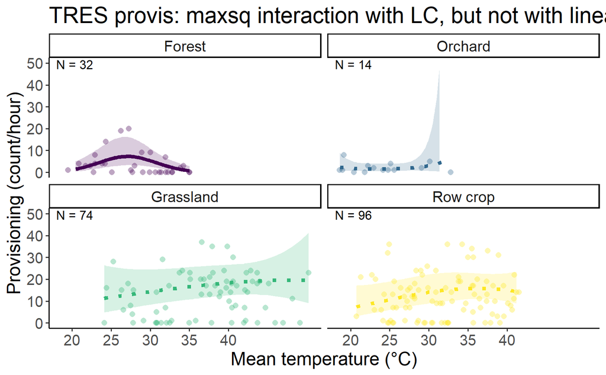

```r
(fig5_tres <- ggpredict(m,terms = c("mean_temp_scaled [all]","habitat"),bias_correction = TRUE) %>%
    plot(line_size = 1.5,alpha = .2,show_data = TRUE,limit_range = TRUE) +
    aes(linetype = .data[["group"]]) +
    theme_classic() +
    facet_wrap(~ group, ncol = 2) +
    xlab("Mean temperature (\u00b0C)") +
    ylab("Provisioning (count/hour)") +
    scale_fill_viridis(discrete = TRUE) +
    scale_color_viridis(discrete = TRUE) +
    theme(text = element_text(size = 16)) +
    labs(title = "TRES provis: maxsq interaction with LC, but not with linear max") +
    scale_x_continuous(trans = temp_trans_tres,
                       breaks = c((20-mean_temp_tres)/sd_temp_tres,
                                  (25-mean_temp_tres)/sd_temp_tres,
                                  (30-mean_temp_tres)/sd_temp_tres,
                                  (35-mean_temp_tres)/sd_temp_tres,
                                  (40-mean_temp_tres)/sd_temp_tres),
                       # breaks = c(20,30,40,50),
                       # labels = c("20","30","40","50"),
                       # limits = c((15-mean(g$meanmaxtempI,na.rm = TRUE))/sd(g$meanmaxtempI,na.rm = TRUE),
                       #            (55-mean(g$meanmaxtempI,na.rm = TRUE))/sd(g$meanmaxtempI,na.rm = TRUE))
                       # limits = c(18,5)
    ) +
    scale_linetype_manual(values = c("Forest" = "solid","Orchard" = "dotted","Grassland" = "dotted","Row crop" = "dotted")) +
    ylim(0,50) +
    geom_text(data = dat_text_tres, mapping = aes(x = -Inf, y = Inf,label = label),hjust = -.2, vjust = 1.2,inherit.aes = FALSE) +
    theme(legend.position = "none")
)
```

```
G3;Data points may overlap. Use the `jitter` argument to add some amount of random variation to the
  location of data points and avoid overplotting.
g
```

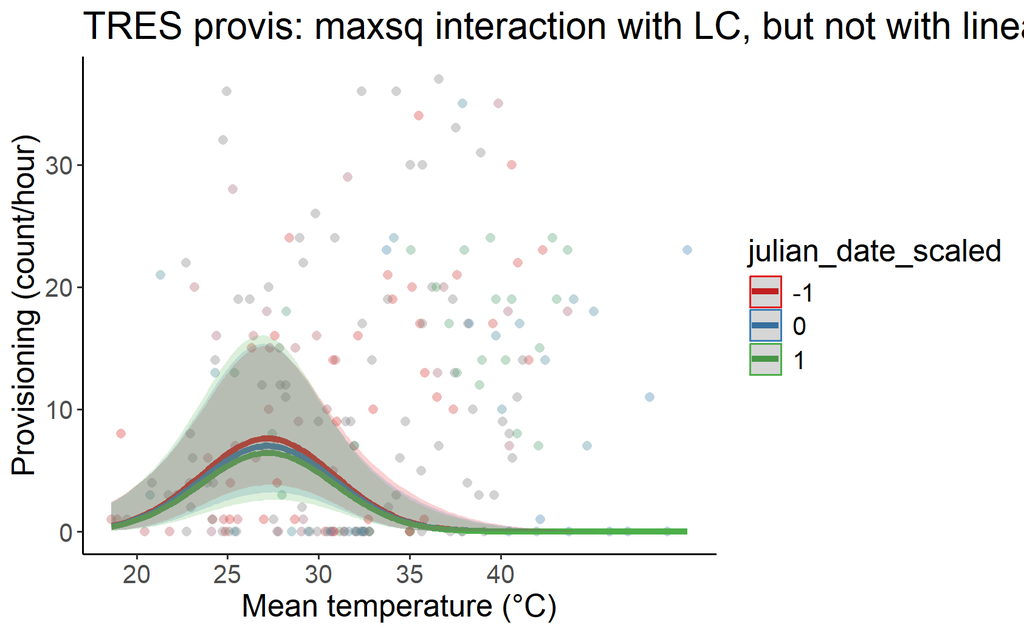

```r
(fig5_tres <- ggpredict(prior_model,terms = c("mean_temp_scaled [all]","julian_date_scaled"),bias_correction = TRUE) %>%
    plot(line_size = 1.5,alpha = .2,show_data = TRUE,limit_range = TRUE) +
    # aes(linetype = .data[["group"]]) +
    theme_classic() +
    # facet_wrap(~ group, ncol = 2) +
    xlab("Mean temperature (\u00b0C)") +
    ylab("Provisioning (count/hour)") +
    # scale_fill_viridis(discrete = TRUE) +
    # scale_color_viridis(discrete = TRUE) +
    theme(text = element_text(size = 16)) +
    labs(title = "TRES provis: maxsq interaction with LC, but not with linear max") +
    scale_x_continuous(trans = temp_trans_tres,
                       breaks = c((20-mean_temp_tres)/sd_temp_tres,
                                  (25-mean_temp_tres)/sd_temp_tres,
                                  (30-mean_temp_tres)/sd_temp_tres,
                                  (35-mean_temp_tres)/sd_temp_tres,
                                  (40-mean_temp_tres)/sd_temp_tres),
                       # breaks = c(20,30,40,50),
                       # labels = c("20","30","40","50"),
                       # limits = c((15-mean(g$meanmaxtempI,na.rm = TRUE))/sd(g$meanmaxtempI,na.rm = TRUE),
                       #            (55-mean(g$meanmaxtempI,na.rm = TRUE))/sd(g$meanmaxtempI,na.rm = TRUE))
                       # limits = c(18,5)
    ) # +
    # scale_linetype_manual(values = c("Forest" = "solid","Orchard" = "dotted","Grassland" = "dotted","Row crop" = "dotted")) +
    # ylim(0,50) +
    # geom_text(data = dat_text_tres, mapping = aes(x = -Inf, y = Inf,label = label),hjust = -.2, vjust = 1.2,inherit.aes = FALSE) +
    # theme(legend.position = "none")
)
```

Interaction is not significant

```r
growth <- rbind(weblgrowthtrendmax_prior$`_data`,tresgrowthtrendmax_prior$`_data`,
```

[output not shown]

```r
                weblgrowthtrendmax$`_data`,tresgrowthtrendmax$`_data`) %>%
  rename(Trend = "Max temp trend",`Statistic` = "T-ratio",`P-value` = "P") %>%
  mutate(Species = rep(c(rep("Western Bluebird",4),rep("Tree Swallow",4)),2),
         Response = "Growth ~ Mean max temperature over prior week",
         Model = c(rep("No maximum temperature * day of year interaction",8),
                       rep("Maximum temperature * day of year interaction",8)),
         sig = if_else(`P-value` == "<0.001","***",
                       if_else(as.numeric(`P-value`) < .01, "**",
                               if_else(as.numeric(`P-value`) < .05,"*",""))),
         Estimate = paste0(as.character(Trend),sig),
         Predictor = "Mean max temperature over prior week") %>%
  dplyr::select(Species, Response, Model, Habitat, Estimate) %>%
  group_by(Response) %>%
  pivot_longer(-c(Species, Response, Model,Habitat)) %>%
  pivot_wider(names_from=c(Species, Habitat), values_from=value) %>%
  dplyr::select(-name)
```

```
G2;H2;Warningh: There were 2 warnings in `mutate()`.
The first warning was:
ℹ In argument: `sig = if_else(...)`.
Caused by warning in `is_logical()`:
! NAs introduced by coercion
ℹ Run ]8;;ide:run:dplyr::last_dplyr_warnings()dplyr::last_dplyr_warnings() to see the 1 remaining warning.g
```

```r
survival <- rbind(weblsurvival_nestpd_trendmax_prior$`_data`,tressurvival_nestpd_trendmax_prior$`_data`,
                weblsurvival_nestpd_trendmax$`_data`,tressurvival_nestpd_trendmax$`_data`) %>%
  rename(Trend = "Max temp trend",`Statistic` = "T-ratio",`P-value` = "P") %>%
  mutate(Species = rep(c(rep("Western Bluebird",4),rep("Tree Swallow",4)),2),
         Response = "Survival ~ Mean max temperature over prior week",
         Model = c(rep("No maximum temperature * day of year interaction",8),
                       rep("Maximum temperature * day of year interaction",8)),
         sig = if_else(`P-value` == "<0.001","***",
                       if_else(as.numeric(`P-value`) < .01, "**",
                               if_else(as.numeric(`P-value`) < .05,"*",""))),
         Estimate = paste0(as.character(Trend),sig),
         Predictor = "Mean max temperature over prior week") %>%
  dplyr::select(Species, Response, Model, Habitat, Estimate) %>%
  group_by(Response) %>%
  pivot_longer(-c(Species, Response, Model,Habitat)) %>%
  pivot_wider(names_from=c(Species, Habitat), values_from=value) %>%
  dplyr::select(-name)

s1_priorday <- rbind(webls1_priordayt_trendmax_prior$`_data`,tress1_priordayt_trendmax_prior$`_data`,
                webls1_priordayt_trendmax$`_data`,tress1_priordayt_trendmax$`_data`) %>%
  rename(Trend = "Max temp trend",`Statistic` = "T-ratio",`P-value` = "P") %>%
  mutate(Species = rep(c(rep("Western Bluebird",4),rep("Tree Swallow",4)),2),
         Response = "Baseline corticosterone ~ Maximum temperature of the prior day",
         Model = c(rep("No maximum temperature * day of year interaction",8),
                       rep("Maximum temperature * day of year interaction",8)),
         sig = if_else(`P-value` == "<0.001","***",
                       if_else(as.numeric(`P-value`) < .01, "**",
                               if_else(as.numeric(`P-value`) < .05,"*",""))),
         Estimate = paste0(as.character(Trend),sig),
         Predictor = "Mean max temperature over prior week") %>%
  dplyr::select(Species, Response, Model, Habitat, Estimate) %>%
  group_by(Response) %>%
  pivot_longer(-c(Species, Response, Model,Habitat)) %>%
  pivot_wider(names_from=c(Species, Habitat), values_from=value) %>%
  dplyr::select(-name)

s1_priorweek <- rbind(webls1trendmax_prior$`_data`,tress1trendmax_prior$`_data`,
                webls1trendmax$`_data`,tress1trendmax$`_data`) %>%
  rename(Trend = "Max temp trend",`Statistic` = "T-ratio",`P-value` = "P") %>%
  mutate(Species = rep(c(rep("Western Bluebird",4),rep("Tree Swallow",4)),2),
         Response = "Baseline corticosterone ~ Mean max temperature of the prior week",
         Model = c(rep("No maximum temperature * day of year interaction",8),
                       rep("Maximum temperature * day of year interaction",8)),
         sig = if_else(`P-value` == "<0.001","***",
                       if_else(as.numeric(`P-value`) < .01, "**",
                               if_else(as.numeric(`P-value`) < .05,"*",""))),
         Estimate = paste0(as.character(Trend),sig),
         Predictor = "Mean max temperature over prior week") %>%
  dplyr::select(Species, Response, Model, Habitat, Estimate) %>%
  group_by(Response) %>%
  pivot_longer(-c(Species, Response, Model,Habitat)) %>%
  pivot_wider(names_from=c(Species, Habitat), values_from=value) %>%
  dplyr::select(-name)

abs_priorday <- rbind(weblabs_priordayt_trendmax_prior$`_data`,tresabs_priordayt_trendmax_prior$`_data`,
                weblabs_priordayt_trendmax$`_data`,tresabs_priordayt_trendmax$`_data`) %>%
  rename(Trend = "Max temp trend",`Statistic` = "T-ratio",`P-value` = "P") %>%
  mutate(Species = rep(c(rep("Western Bluebird",4),rep("Tree Swallow",4)),2),
         Response = "Difference between stress-induced and baseline corticosterone ~ Maximum temperature of the prior day",
         Model = c(rep("No maximum temperature * day of year interaction",8),
                       rep("Maximum temperature * day of year interaction",8)),
         sig = if_else(`P-value` == "<0.001","***",
                       if_else(as.numeric(`P-value`) < .01, "**",
                               if_else(as.numeric(`P-value`) < .05,"*",""))),
         Estimate = paste0(as.character(Trend),sig),
         Predictor = "Mean max temperature over prior week") %>%
  dplyr::select(Species, Response, Model, Habitat, Estimate) %>%
  group_by(Response) %>%
  pivot_longer(-c(Species, Response, Model,Habitat)) %>%
  pivot_wider(names_from=c(Species, Habitat), values_from=value) %>%
  dplyr::select(-name)

abs_priorweek <- rbind(weblabstrendmax_prior$`_data`,tresabstrendmax_prior$`_data`,
                weblabstrendmax$`_data`,tresabstrendmax$`_data`) %>%
  rename(Trend = "Max temp trend",`Statistic` = "T-ratio",`P-value` = "P") %>%
  mutate(Species = rep(c(rep("Western Bluebird",4),rep("Tree Swallow",4)),2),
         Response = "Difference between stress-induced and baseline corticosterone ~ Mean max temperature of the prior week",
         Model = c(rep("No maximum temperature * day of year interaction",8),
                       rep("Maximum temperature * day of year interaction",8)),
         sig = if_else(`P-value` == "<0.001","***",
                       if_else(as.numeric(`P-value`) < .01, "**",
                               if_else(as.numeric(`P-value`) < .05,"*",""))),
         Estimate = paste0(as.character(Trend),sig),
         Predictor = "Mean max temperature over prior week") %>%
  dplyr::select(Species, Response, Model, Habitat, Estimate) %>%
  group_by(Response) %>%
  pivot_longer(-c(Species, Response, Model,Habitat)) %>%
  pivot_wider(names_from=c(Species, Habitat), values_from=value) %>%
  dplyr::select(-name)

s2_priorday <- rbind(webls2_priordayt_trendmax_prior$`_data`,tress2_priordayt_trendmax_prior$`_data`,
                webls2_priordayt_trendmax$`_data`,tress2_priordayt_trendmax$`_data`) %>%
  rename(Trend = "Max temp trend",`Statistic` = "T-ratio",`P-value` = "P") %>%
  mutate(Species = rep(c(rep("Western Bluebird",4),rep("Tree Swallow",4)),2),
         Response = "Stres-induced corticosterone ~ Maximum temperature of the prior day",
         Model = c(rep("No maximum temperature * day of year interaction",8),
                       rep("Maximum temperature * day of year interaction",8)),
         sig = if_else(`P-value` == "<0.001","***",
                       if_else(as.numeric(`P-value`) < .01, "**",
                               if_else(as.numeric(`P-value`) < .05,"*",""))),
         Estimate = paste0(as.character(Trend),sig),
         Predictor = "Mean max temperature over prior week") %>%
  dplyr::select(Species, Response, Model, Habitat, Estimate) %>%
  group_by(Response) %>%
  pivot_longer(-c(Species, Response, Model,Habitat)) %>%
  pivot_wider(names_from=c(Species, Habitat), values_from=value) %>%
  dplyr::select(-name)

s2_priorweek <- rbind(webls2trendmax_prior$`_data`,tress2trendmax_prior$`_data`,
                webls2trendmax$`_data`,tress2trendmax$`_data`) %>%
  rename(Trend = "Max temp trend",`Statistic` = "T-ratio",`P-value` = "P") %>%
  mutate(Species = rep(c(rep("Western Bluebird",4),rep("Tree Swallow",4)),2),
         Response = "Stress-induced corticosterone ~ Mean max temperature of the prior week",
         Model = c(rep("No maximum temperature * day of year interaction",8),
                       rep("Maximum temperature * day of year interaction",8)),
         sig = if_else(`P-value` == "<0.001","***",
                       if_else(as.numeric(`P-value`) < .01, "**",
                               if_else(as.numeric(`P-value`) < .05,"*",""))),
         Estimate = paste0(as.character(Trend),sig),
         Predictor = "Mean max temperature over prior week") %>%
  dplyr::select(Species, Response, Model, Habitat, Estimate) %>%
  group_by(Response) %>%
  pivot_longer(-c(Species, Response, Model,Habitat)) %>%
  pivot_wider(names_from=c(Species, Habitat), values_from=value) %>%
  dplyr::select(-name)

provis <- rbind(weblprovistrend_prior$`_data` %>% mutate(degree = "linear"),tresprovistrend_prior$`_data`,
                weblprovistrend$`_data` %>% mutate(degree = "linear"),tresprovistrend$`_data`) %>%
  rename(Trend = "Max temp trend",`Statistic` = "Z-ratio",`P-value` = "P") %>%
  mutate(Species = rep(c(rep("Western Bluebird",4),rep("Tree Swallow",8)),2),
         Response = "Provisioning ~ Average hourly temperature",
         Model = c(rep("No maximum temperature * day of year interaction",12),
                       rep("Maximum temperature * day of year interaction",12)),
         sig = if_else(`P-value` == "<0.001","***",
                       if_else(as.numeric(`P-value`) < .01, "**",
                               if_else(as.numeric(`P-value`) < .05,"*",""))),
         Estimate = paste0(as.character(Trend),sig),
         Predictor = "Mean max temperature over prior week") %>%
  dplyr::select(Species, Response, Model, Habitat, Estimate, degree) %>%
  pivot_wider(names_from = degree,values_from = Estimate) %>%
  mutate(quadratic = replace_na(quadratic, "NA"),
         Estimate = paste0(linear,", ",quadratic)) %>%
  dplyr::select(-c(linear,quadratic)) %>%
  group_by(Response) %>%
  pivot_longer(-c(Species, Response, Model,Habitat)) %>%
  pivot_wider(names_from=c(Species, Habitat), values_from=value) %>%
  dplyr::select(-name)
```

```
G2;H2;Warningh: There were 2 warnings in `mutate()`.
The first warning was:
ℹ In argument: `sig = if_else(...)`.
Caused by warning in `is_logical()`:
! NAs introduced by coercion
ℹ Run ]8;;ide:run:dplyr::last_dplyr_warnings()dplyr::last_dplyr_warnings() to see the 1 remaining warning.g
```

```r
(trend <- rbind(growth,survival,s1_priorday,s1_priorweek,abs_priorday,abs_priorweek,s2_priorday,s2_priorweek,provis) %>% gt(rowname_col = "Model",groupname_col = "Response") %>% tab_options(data_row.padding = px(1)) %>%
```

[output not shown]

```r
  tab_spanner_delim(
    delim="_"))
```

[output not shown]

```r
gtsave(trend,"../figures/val_tbl.html")
```